# Prediction of loan defaults

Naga Chaitanya Paladugu

2024-07-15

# Introduction

## I1: Source of Dataset

The source of my dataset is the UCI Machine Learning Repository.

Link: [UCI Machine Learning Repository - Default of Credit Card Clients Dataset](https://archive.ics.uci.edu/ml/datasets/default+of+credit+card+clients)

## I2: Context

In 2005, Taiwan faced a consumer financial crisis, known as the double-card crisis, due to overwhelming debt from credit and cash cards. More than half a million cardholders, according to “The Taiwan Credit Card Crisis - Financial Ethics” (2011), were unable to repay their debts, leading to social issues and increased crime rates. Financial institutions experienced sharp rises in overdue and default rates, with some nearly going bankrupt. This crisis also slowed consumer spending and economic growth. The government had to intervene with financial aid and regulatory reforms to stabilize the economy and prevent further damage.

Using this case study, I will build a machine learning model to predict credit card loan defaults for the month of October 2005 using demographic and past payment behavior. The model will employ a Bayesian approach to fit a logistic regression, aiming to identify potential defaulters and improve credit risk management.

## Objective

Straight to the point, our goal is to predict whether or not a customer defaults (*Yes* or *No*) on their loan repayment for the month of October 2005, indicated by ‘*default payment next month*,’ using various demographic and payment behavior of past six months as feature variables. Considering the high default rates in the country, our main focus is to effectively predict potential defaulters rather than aiming for overall accuracy.

## I3: Permission Requirements

I have permission to share the dataset and its analysis, as the dataset is publicly available from the UCI Machine Learning Repository for research and educational purposes. Appropriate credit is given to the UCI Machine Learning Repository by citing it in this report.

## I4: Compilation

I compiled the dataset by downloading it from the UCI Machine Learning Repository, renaming it to “*UCI_CreditCard.xlsx*” for local use, and preprocessing it to ensure consistency and accuracy. This included handling missing values, adjusting variable classes, renaming variables, creating new features, and transforming variables as needed for the analysis.

## I5: Dataset Description

The dataset includes 30,000 observations and 25 variables. Key variables include:

- Demographic Details: Age, gender, marital status, education level.
- Past Payment Behavior: Payment history, bill amounts, previous default status.
- Target Variable: ‘Default payment next month,’ indicating whether a client defaulted on their loan repayment in October 2005.

[output not shown]

## I6: Research Questions

1. What are the key features that significantly predict whether a client will default on their credit card payments?
2. In predicting credit card default rates, which category—demographic factors or past payment behaviors—provides more significant insights or predictive power?

# Bringing in the Dataset

Let’s bring it in and see the structure.

```r
# Set the working directory
setwd("~/Simulation and Modelling/FinalProject")

# List files in the directory to confirm dataset presence
dir()
```

```
## [1] "NagaChaitanya_Paladugu_FinalProject.Rmd"
## [2] "NagaChaitanya_Paladugu_FinalProject.Rmd.Rmd"
## [3] "Project_file.R"
## [4] "R2.R"
## [5] "UCI_CreditCard.xlsx.xls"
```

```r
# Load necessary library
library(readxl)

# Read the dataset
taiwan_loan <- read_excel("UCI_CreditCard.xlsx.xls")
# Display the structure of the dataset
str(taiwan_loan)
```

```
## tibble [30,001 × 25] (S3: tbl_df/tbl/data.frame)
##  $ ...1: chr [1:30001] "ID" "1" "2" "3" ...
##  $ X1  : chr [1:30001] "LIMIT_BAL" "20000" "120000" "90000" ...
##  $ X2  : chr [1:30001] "SEX" "2" "2" "2" ...
##  $ X3  : chr [1:30001] "EDUCATION" "2" "2" "2" ...
##  $ X4  : chr [1:30001] "MARRIAGE" "1" "2" "2" ...
##  $ X5  : chr [1:30001] "AGE" "24" "26" "34" ...
##  $ X6  : chr [1:30001] "PAY_0" "2" "-1" "0" ...
##  $ X7  : chr [1:30001] "PAY_2" "2" "2" "0" ...
##  $ X8  : chr [1:30001] "PAY_3" "-1" "0" "0" ...
##  $ X9  : chr [1:30001] "PAY_4" "-1" "0" "0" ...
##  $ X10 : chr [1:30001] "PAY_5" "-2" "0" "0" ...
##  $ X11 : chr [1:30001] "PAY_6" "-2" "2" "0" ...
##  $ X12 : chr [1:30001] "BILL_AMT1" "3913" "2682" "29239" ...
##  $ X13 : chr [1:30001] "BILL_AMT2" "3102" "1725" "14027" ...
##  $ X14 : chr [1:30001] "BILL_AMT3" "689" "2682" "13559" ...
##  $ X15 : chr [1:30001] "BILL_AMT4" "0" "3272" "14331" ...
##  $ X16 : chr [1:30001] "BILL_AMT5" "0" "3455" "14948" ...
##  $ X17 : chr [1:30001] "BILL_AMT6" "0" "3261" "15549" ...
##  $ X18 : chr [1:30001] "PAY_AMT1" "0" "0" "1518" ...
##  $ X19 : chr [1:30001] "PAY_AMT2" "689" "1000" "1500" ...
##  $ X20 : chr [1:30001] "PAY_AMT3" "0" "1000" "1000" ...
##  $ X21 : chr [1:30001] "PAY_AMT4" "0" "1000" "1000" ...
##  $ X22 : chr [1:30001] "PAY_AMT5" "0" "0" "1000" ...
##  $ X23 : chr [1:30001] "PAY_AMT6" "0" "2000" "5000" ...
##  $ Y   : chr [1:30001] "default payment next month" "1" "1" "0" ...
```

It is clear from the dataset that the class of all variables is inappropriate, and the column names are mislabelled, with the appropriate ones coded in the 1st row of the table.

# Data Cleaning

```r
# Extract the first row to use as the header
header <- taiwan_loan[1, ]

# Set the first row as the column names
colnames(taiwan_loan) <- header

# Remove the first row (variable names)
taiwan_loan <- taiwan_loan[-1, ]

# Display the structure of the dataset
str(taiwan_loan)
```

```
## tibble [30,000 × 25] (S3: tbl_df/tbl/data.frame)
##  $ ID                        : chr [1:30000] "1" "2" "3" "4" ...
##  $ LIMIT_BAL                 : chr [1:30000] "20000" "120000" "90000" "50000" ...
##  $ SEX                       : chr [1:30000] "2" "2" "2" "2" ...
##  $ EDUCATION                 : chr [1:30000] "2" "2" "2" "2" ...
##  $ MARRIAGE                  : chr [1:30000] "1" "2" "2" "1" ...
##  $ AGE                       : chr [1:30000] "24" "26" "34" "37" ...
##  $ PAY_0                     : chr [1:30000] "2" "-1" "0" "0" ...
##  $ PAY_2                     : chr [1:30000] "2" "2" "0" "0" ...
##  $ PAY_3                     : chr [1:30000] "-1" "0" "0" "0" ...
##  $ PAY_4                     : chr [1:30000] "-1" "0" "0" "0" ...
##  $ PAY_5                     : chr [1:30000] "-2" "0" "0" "0" ...
##  $ PAY_6                     : chr [1:30000] "-2" "2" "0" "0" ...
##  $ BILL_AMT1                 : chr [1:30000] "3913" "2682" "29239" "46990" ...
##  $ BILL_AMT2                 : chr [1:30000] "3102" "1725" "14027" "48233" ...
##  $ BILL_AMT3                 : chr [1:30000] "689" "2682" "13559" "49291" ...
##  $ BILL_AMT4                 : chr [1:30000] "0" "3272" "14331" "28314" ...
##  $ BILL_AMT5                 : chr [1:30000] "0" "3455" "14948" "28959" ...
##  $ BILL_AMT6                 : chr [1:30000] "0" "3261" "15549" "29547" ...
##  $ PAY_AMT1                  : chr [1:30000] "0" "0" "1518" "2000" ...
##  $ PAY_AMT2                  : chr [1:30000] "689" "1000" "1500" "2019" ...
##  $ PAY_AMT3                  : chr [1:30000] "0" "1000" "1000" "1200" ...
##  $ PAY_AMT4                  : chr [1:30000] "0" "1000" "1000" "1100" ...
##  $ PAY_AMT5                  : chr [1:30000] "0" "0" "1000" "1069" ...
##  $ PAY_AMT6                  : chr [1:30000] "0" "2000" "5000" "1000" ...
##  $ default payment next month: chr [1:30000] "1" "1" "0" "0" ...
```

We shall better rename the variables to more meaningful names, change the variables into appropriate class, drop the unnecessary ID column, and verify the changes to ensure the dataset is properly structured for further analysis.

```r
# Load necessary library
library(dplyr)
# Rename variables and convert to appropriate classes
taiwan_loan <- taiwan_loan %>%
  rename(
    Credit_Limit = LIMIT_BAL,
    Gender = SEX,
    Edu_Level = EDUCATION,
    Marital_Status = MARRIAGE,
    Age = AGE,
    Pay_Status_Sept = PAY_0,
    Pay_Status_Aug = PAY_2,
    Pay_Status_July = PAY_3,
    Pay_Status_June = PAY_4,
    Pay_Status_May = PAY_5,
    Pay_Status_April = PAY_6,
    Bill_Amt_Sept = BILL_AMT1,
    Bill_Amt_Aug = BILL_AMT2,
    Bill_Amt_July = BILL_AMT3,
    Bill_Amt_June = BILL_AMT4,
    Bill_Amt_May = BILL_AMT5,
    Bill_Amt_April = BILL_AMT6,
    Pay_Amt_Sept = PAY_AMT1,
    Pay_Amt_Aug = PAY_AMT2,
    Pay_Amt_July = PAY_AMT3,
    Pay_Amt_June = PAY_AMT4,
    Pay_Amt_May = PAY_AMT5,
    Pay_Amt_April = PAY_AMT6,
    Default = "default payment next month"
  ) %>%
  select(-ID) %>%
  mutate(
    Credit_Limit= as.numeric(Credit_Limit),
    Gender = as.factor(Gender),
    Edu_Level = as.factor(Edu_Level),
    Marital_Status = as.factor(Marital_Status),
    Age = as.numeric(Age),
    Pay_Status_Sept = as.factor(Pay_Status_Sept),
    Pay_Status_Aug = as.factor(Pay_Status_Aug),
    Pay_Status_July = as.factor(Pay_Status_July),
    Pay_Status_June = as.factor(Pay_Status_June),
    Pay_Status_May = as.factor(Pay_Status_May),
    Pay_Status_April = as.factor(Pay_Status_April),
    Bill_Amt_Sept = as.numeric(Bill_Amt_Sept),
    Bill_Amt_Aug = as.numeric(Bill_Amt_Aug),
    Bill_Amt_July = as.numeric(Bill_Amt_July),
    Bill_Amt_June = as.numeric(Bill_Amt_June),
    Bill_Amt_May = as.numeric(Bill_Amt_May),
    Bill_Amt_April = as.numeric(Bill_Amt_April),
    Pay_Amt_Sept = as.numeric(Pay_Amt_Sept),
    Pay_Amt_Aug = as.numeric(Pay_Amt_Aug),
    Pay_Amt_July = as.numeric(Pay_Amt_July),
    Pay_Amt_June = as.numeric(Pay_Amt_June),
    Pay_Amt_May = as.numeric(Pay_Amt_May),
    Pay_Amt_April = as.numeric(Pay_Amt_April),
    Default = as.factor(Default)
  )

# Verify the changes
str(taiwan_loan)
```

```
## tibble [30,000 × 24] (S3: tbl_df/tbl/data.frame)
##  $ Credit_Limit    : num [1:30000] 20000 120000 90000 50000 50000 50000 500000 100000 140000 20000 ...
##  $ Gender          : Factor w/ 2 levels "1","2": 2 2 2 2 1 1 1 2 2 1 ...
##  $ Edu_Level       : Factor w/ 7 levels "0","1","2","3",..: 3 3 3 3 3 2 2 3 4 4 ...
##  $ Marital_Status  : Factor w/ 4 levels "0","1","2","3": 2 3 3 2 2 3 3 3 2 3 ...
##  $ Age             : num [1:30000] 24 26 34 37 57 37 29 23 28 35 ...
##  $ Pay_Status_Sept : Factor w/ 11 levels "-1","-2","0",..: 5 1 3 3 1 3 3 3 3 2 ...
##  $ Pay_Status_Aug  : Factor w/ 11 levels "-1","-2","0",..: 5 5 3 3 3 3 3 1 3 2 ...
##  $ Pay_Status_July : Factor w/ 11 levels "-1","-2","0",..: 1 3 3 3 1 3 3 1 5 2 ...
##  $ Pay_Status_June : Factor w/ 11 levels "-1","-2","0",..: 1 3 3 3 3 3 3 3 3 2 ...
##  $ Pay_Status_May  : Factor w/ 10 levels "-1","-2","0",..: 2 3 3 3 3 3 3 3 3 1 ...
##  $ Pay_Status_April: Factor w/ 10 levels "-1","-2","0",..: 2 4 3 3 3 3 3 1 3 1 ...
##  $ Bill_Amt_Sept   : num [1:30000] 3913 2682 29239 46990 8617 ...
##  $ Bill_Amt_Aug    : num [1:30000] 3102 1725 14027 48233 5670 ...
##  $ Bill_Amt_July   : num [1:30000] 689 2682 13559 49291 35835 ...
##  $ Bill_Amt_June   : num [1:30000] 0 3272 14331 28314 20940 ...
##  $ Bill_Amt_May    : num [1:30000] 0 3455 14948 28959 19146 ...
##  $ Bill_Amt_April  : num [1:30000] 0 3261 15549 29547 19131 ...
##  $ Pay_Amt_Sept    : num [1:30000] 0 0 1518 2000 2000 ...
##  $ Pay_Amt_Aug     : num [1:30000] 689 1000 1500 2019 36681 ...
##  $ Pay_Amt_July    : num [1:30000] 0 1000 1000 1200 10000 657 38000 0 432 0 ...
##  $ Pay_Amt_June    : num [1:30000] 0 1000 1000 1100 9000 ...
##  $ Pay_Amt_May     : num [1:30000] 0 0 1000 1069 689 ...
##  $ Pay_Amt_April   : num [1:30000] 0 2000 5000 1000 679 ...
##  $ Default         : Factor w/ 2 levels "0","1": 2 2 1 1 1 1 1 1 1 1 ...
```

Let’s check for any missing data.

```r
# Check for NA values
colSums(is.na(taiwan_loan))
```

```
##     Credit_Limit           Gender        Edu_Level   Marital_Status
##                0                0                0                0
##              Age  Pay_Status_Sept   Pay_Status_Aug  Pay_Status_July
##                0                0                0                0
##  Pay_Status_June   Pay_Status_May Pay_Status_April    Bill_Amt_Sept
##                0                0                0                0
##     Bill_Amt_Aug    Bill_Amt_July    Bill_Amt_June     Bill_Amt_May
##                0                0                0                0
##   Bill_Amt_April     Pay_Amt_Sept      Pay_Amt_Aug     Pay_Amt_July
##                0                0                0                0
##     Pay_Amt_June      Pay_Amt_May    Pay_Amt_April          Default
##                0                0                0                0
```

With the absence of null values and the sufficiently clean enough dataset in hand, we can proceed with the Exploratory Data Analysis (EDA).

# EDA and Transformation

### Categorical

#### Gender

Let’s explore the *Gender* variable to understand its distribution and relationship with the default status. From the information we have, Gender: 1 = male; 2 = female.

```r
#Gender
table(taiwan_loan$Gender)
```

```
##
##     1     2
## 11888 18112
```

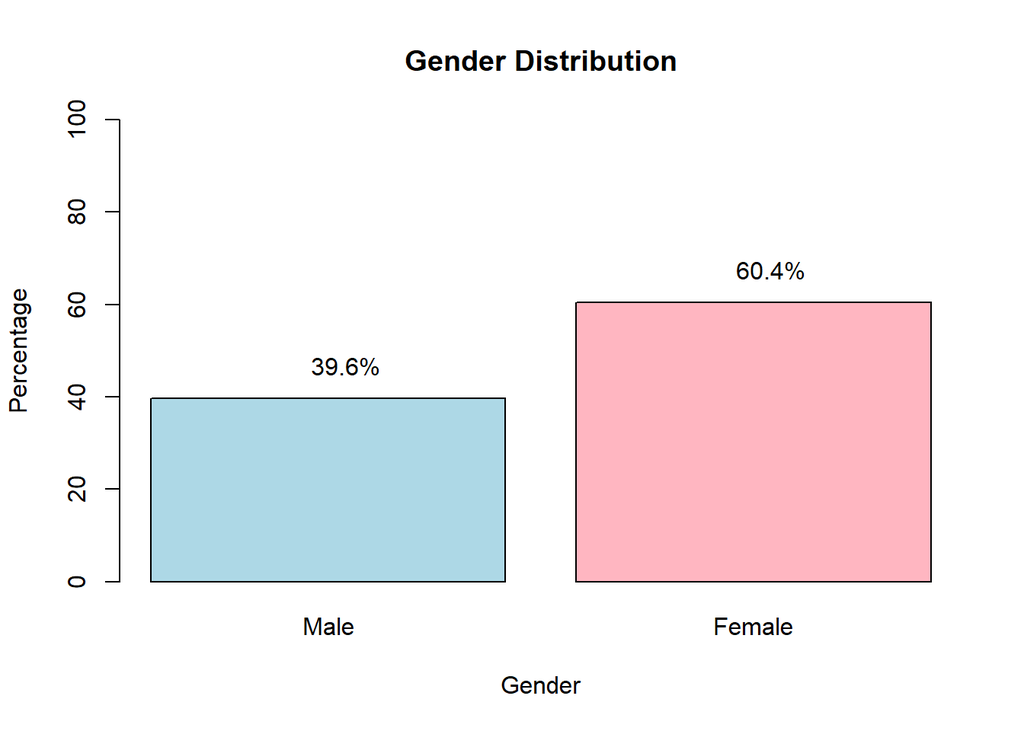

```r
# Gender: 1 = male; 2 = female
gender_counts <- table(taiwan_loan$Gender)
gender_percentages <- gender_counts / sum(gender_counts) * 100

# Create a bar plot for Gender distribution
barplot(gender_percentages,
        main = "Gender Distribution",
        xlab = "Gender",
        ylab = "Percentage",
        col = c("lightblue", "lightpink"),
        names.arg = c("Male", "Female"),
        ylim = c(0, 100),
        beside = TRUE
)

# Add percentage labels on the bars
text(x = barplot(gender_percentages, plot = FALSE) + 0.05,
     y = gender_percentages + 2,
     labels = paste0(round(gender_percentages, 1), "%"),
     col = "black", pos = 3)
```

Let’s see the how the default rates are for each gender category.

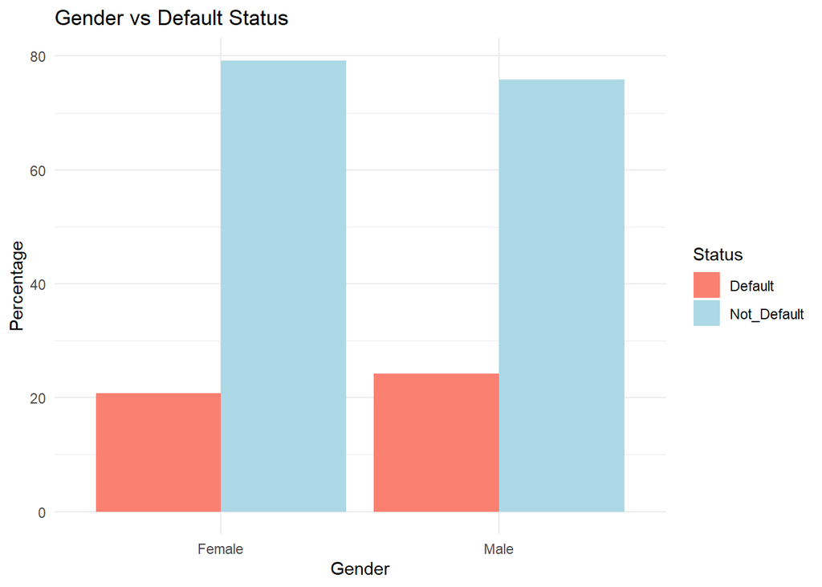

```r
# Assuming gender_default_table and gender_default_percentages are already calculated
gender_default_table <- table(taiwan_loan$Gender, taiwan_loan$Default)
gender_default_percentages <- prop.table(gender_default_table, 1) * 100

# Create a data frame with gender and default status percentages
df <- data.frame(
  Gender = rep(c("Male", "Female"), each = 2),
  Status = rep(c("Not_Default", "Default"), 2),
  Percentage = c(gender_default_percentages[1, ], gender_default_percentages[2, ])
)

# Create the bar plot using ggplot2
library(ggplot2)
ggplot(df, aes(x = Gender, y = Percentage, fill = Status)) +
  geom_bar(stat = "identity", position = position_dodge()) +
  labs(title = "Gender vs Default Status",
       x = "Gender",
       y = "Percentage") +
  scale_fill_manual(values = c("salmon", "lightblue")) +
  theme_minimal()
```

It is clear that although the dataset contains more females taking the credit card loan than males, the default rates are higher in proportion for males than for females.

Although, this suggests us that gender might be an important predictor for default risk, it is essential to be cautious as relying solely on gender for predictions could introduce bias. Therefore, we shall consider other factors and ensure that the model does not unfairly discriminate against any group.

#### Education

Let’s explore the *Edu_Level* variable to understand its distribution and relationship with the default status.

```r
# Check unique values in Education Level
table(taiwan_loan$Edu_Level)
```

```
##
##     0     1     2     3     4     5     6
##    14 10585 14030  4917   123   280    51
```

From the information, *Edu_Level* is coded as: (1 = graduate school; 2 = university; 3 = high school; 4 = others). However, there are classes like 0, 5 and 6 coded into our dataset. Let’s add these *unknown* classes to the “*others*” category as their count is small and would not affect our analysis significantly. Here *others* class could mean education less than high school or something which we are unsure.

```r
# Category reduction for Education Level
taiwan_loan$Edu_Level <- ifelse(as.character(taiwan_loan$Edu_Level) %in% c("0", "5", "6"), "4", as.character(taiwan_loan$Edu_Level))

# Convert back to factor
taiwan_loan$Edu_Level <- as.factor(taiwan_loan$Edu_Level)

# Verify changes
table(taiwan_loan$Edu_Level)
```

```
##
##     1     2     3     4
## 10585 14030  4917   468
```

Let’s see how default rates are distributed for the level of education.

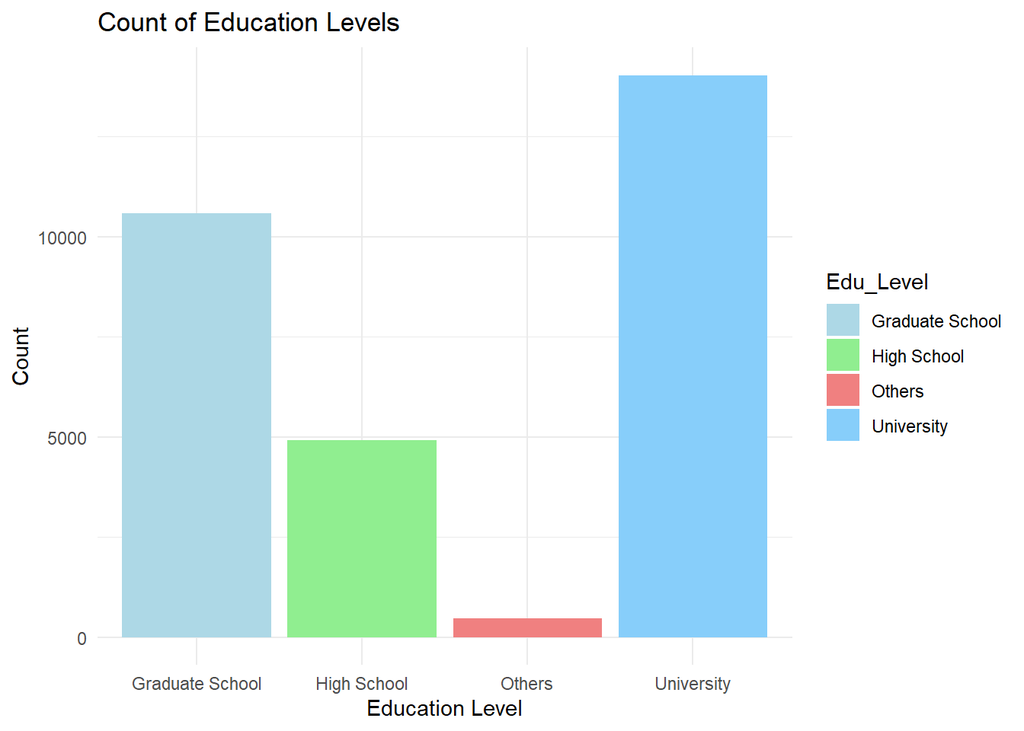

```r
# Create a table for Education Level
edu_level_counts <- table(taiwan_loan$Edu_Level)

# Create a data frame for plotting
edu_count_df <- data.frame(
  Edu_Level = c("Graduate School", "University", "High School", "Others"),
  Count = as.vector(edu_level_counts)
)

# Create the bar plot using ggplot2
library(ggplot2)
ggplot(edu_count_df, aes(x = Edu_Level, y = Count, fill = Edu_Level)) +
  geom_bar(stat = "identity") +
  labs(title = "Count of Education Levels",
       x = "Education Level",
       y = "Count") +
  scale_fill_manual(values = c("lightblue", "lightgreen", "lightcoral", "lightskyblue")) +
  theme_minimal()
```

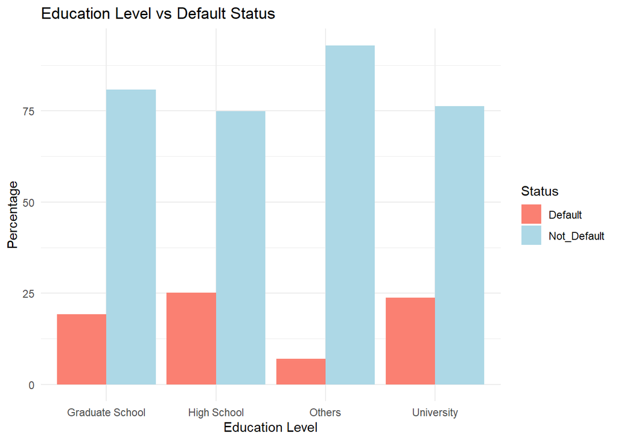

```r
# Create a table for Education Level and Default status
education_default_table <- table(taiwan_loan$Edu_Level, taiwan_loan$Default)
education_default_percentages <- prop.table(education_default_table, 1) * 100

# Create a data frame with education level and default status percentages
edu_df <- data.frame(
  Edu_Level = rep(c("Graduate School", "University", "High School", "Others"), each = 2),
  Status = rep(c("Not_Default", "Default"), 4),
  Percentage = c(education_default_percentages[1, ], education_default_percentages[2, ], education_default_percentages[3, ], education_default_percentages[4, ])
)

# Create the bar plot using ggplot2
library(ggplot2)
ggplot(edu_df, aes(x = Edu_Level, y = Percentage, fill = Status)) +
  geom_bar(stat = "identity", position = position_dodge()) +
  labs(title = "Education Level vs Default Status",
       x = "Education Level",
       y = "Percentage") +
  scale_fill_manual(values = c("salmon", "lightblue")) +
  theme_minimal()
```

The default rates appear to align with the expectation that the more educated a person is, the more financially capable they are of making timely repayments. Excluding the “*Others*” category, whose specifics are unclear, the default rates are lowest among *Graduates* and highest among *high school* passouts within the three main categories.  
Overall, it is plausible that the education level of a person could be used for prediction.

#### Marital Status

Let’s check the distribution of the *Marital_Status* variable and visualize it.

```r
# Check unique values in Marital Status
table(taiwan_loan$Marital_Status)
```

```
##
##     0     1     2     3
##    54 13659 15964   323
```

From our information: Marital status (1 = married; 2 = single; 3 = others). Let’s add the class 0 to 3 as their count (54) is small and would not affect the analysis much.

```r
# Category reduction for Marital Status
taiwan_loan$Marital_Status <- ifelse(as.character(taiwan_loan$Marital_Status) == "0", "3", as.character(taiwan_loan$Marital_Status))

# Convert back to factor
taiwan_loan$Marital_Status <- as.factor(taiwan_loan$Marital_Status)

# Verify changes
table(taiwan_loan$Marital_Status)
```

```
##
##     1     2     3
## 13659 15964   377
```

It is time to view their distributions.

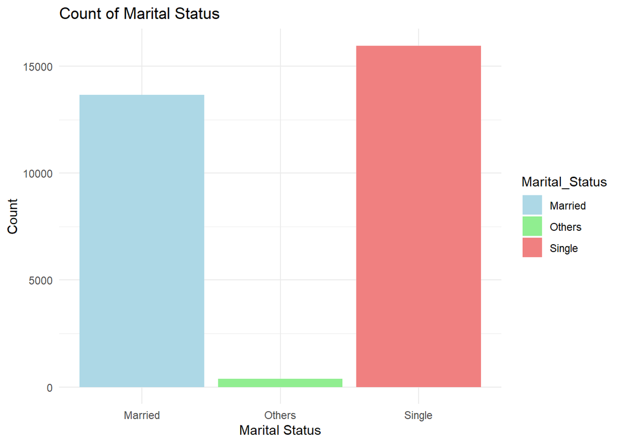

```r
# Create a table for Marital Status
marital_status_counts <- table(taiwan_loan$Marital_Status)

# Create a data frame for plotting
marital_status_df <- data.frame(
  Marital_Status = c("Married", "Single", "Others"),
  Count = as.vector(marital_status_counts)
)

# Create the bar plot using ggplot2
library(ggplot2)
ggplot(marital_status_df, aes(x = Marital_Status, y = Count, fill = Marital_Status)) +
  geom_bar(stat = "identity") +
  labs(title = "Count of Marital Status",
       x = "Marital Status",
       y = "Count") +
  scale_fill_manual(values = c("lightblue", "lightgreen", "lightcoral")) +
  theme_minimal()
```

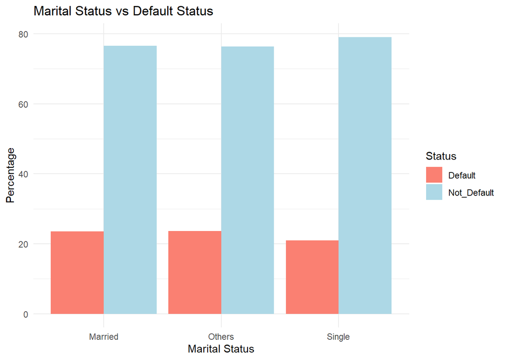

```r
# Create a table for Marital Status and Default status
marital_default_table <- table(taiwan_loan$Marital_Status, taiwan_loan$Default)
marital_default_percentages <- prop.table(marital_default_table, 1) * 100

# Create a data frame with marital status and default status percentages
marital_df <- data.frame(
  Marital_Status = rep(c("Married", "Single", "Others"), each = 2),
  Status = rep(c("Not_Default", "Default"), 3),
  Percentage = c(marital_default_percentages[1, ], marital_default_percentages[2, ], marital_default_percentages[3, ])
)

# Create the bar plot using ggplot2
ggplot(marital_df, aes(x = Marital_Status, y = Percentage, fill = Status)) +
  geom_bar(stat = "identity", position = position_dodge()) +
  labs(title = "Marital Status vs Default Status",
       x = "Marital Status",
       y = "Percentage") +
  scale_fill_manual(values = c("salmon", "lightblue")) +
  theme_minimal()
```

There is not a big difference between the number of married people and single people who took a loan, with singles slightly higher in number. This similarity extends to the proportion of default rates, but default rates are slightly higher among married individuals than singles. Although we don’t exactly know what the “Others” category mean (it could include divorced or never married individuals), there is still a significant proportion of defaults in that class as well.

### Numerical

#### Credit Limit

Let’s explore the *Credit_Limit* variable to understand its distribution and relationship with the default status.

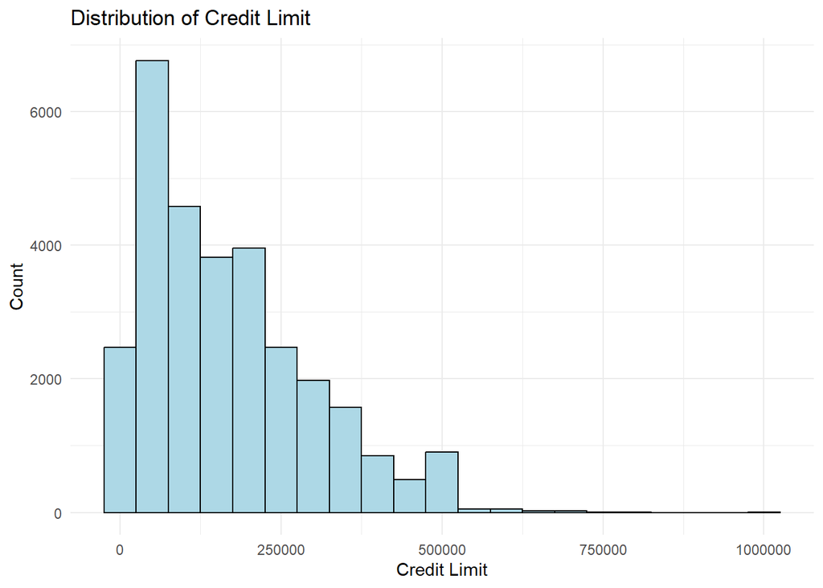

```r
# Create a histogram for Credit Limit
library(ggplot2)
ggplot(taiwan_loan, aes(x = Credit_Limit)) +
  geom_histogram(binwidth = 50000, fill = "lightblue", color = "black") +
  labs(title = "Distribution of Credit Limit",
       x = "Credit Limit",
       y = "Count") +
  theme_minimal()
```

The distribution of credit limits shows that most customers have credit limits concentrated in the range of 0-250K NTD.

Let’s examine the relationship between credit limit and default status.

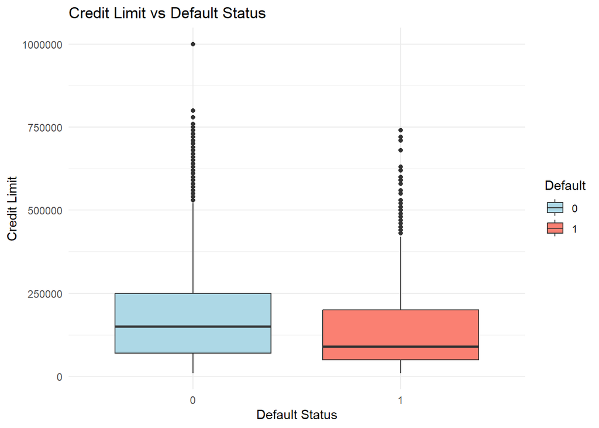

```r
# Create a box plot to visualize the relationship between Credit Limit and Default status
ggplot(taiwan_loan, aes(x = Default, y = Credit_Limit, fill = Default)) +
  geom_boxplot() +
  labs(title = "Credit Limit vs Default Status",
       x = "Default Status",
       y = "Credit Limit") +
  scale_fill_manual(values = c("lightblue", "salmon")) +
  theme_minimal()
```

At first glance, we might think there are outliers with a credit limit of more than 500k NT. However, they could also be high net worth individuals. They are very few in number, which might not affect our analysis much.

#### Age

Let’s see how the age of loan holders is distrbuted.

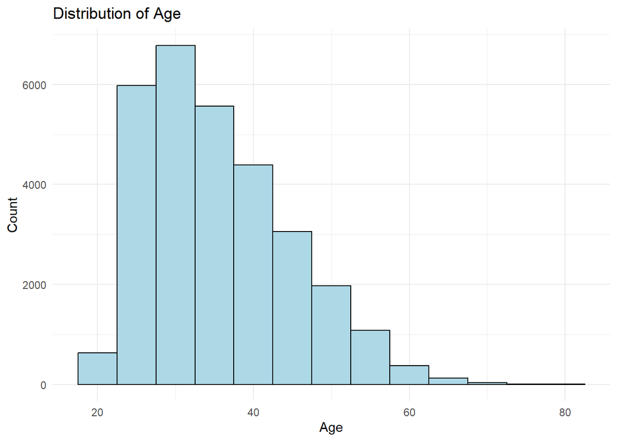

```r
# Distribution Plot
ggplot(taiwan_loan, aes(x = Age)) +
  geom_histogram(binwidth = 5, fill = "lightblue", color = "black") +
  labs(title = "Distribution of Age",
       x = "Age",
       y = "Count") +
  theme_minimal()
```

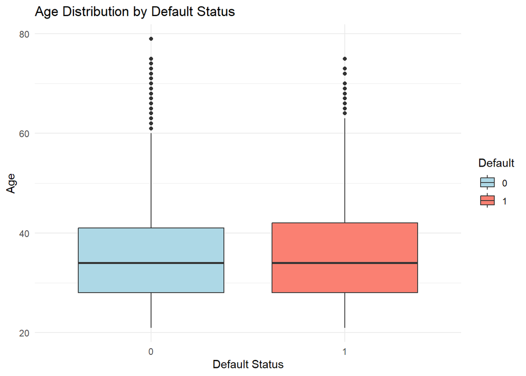

```r
# Box plot of Age by Default Status
ggplot(taiwan_loan, aes(x = Default, y = Age, fill = Default)) +
  geom_boxplot() +
  labs(title = "Age Distribution by Default Status",
       x = "Default Status",
       y = "Age") +
  scale_fill_manual(values = c("lightblue", "salmon")) +
  theme_minimal()
```

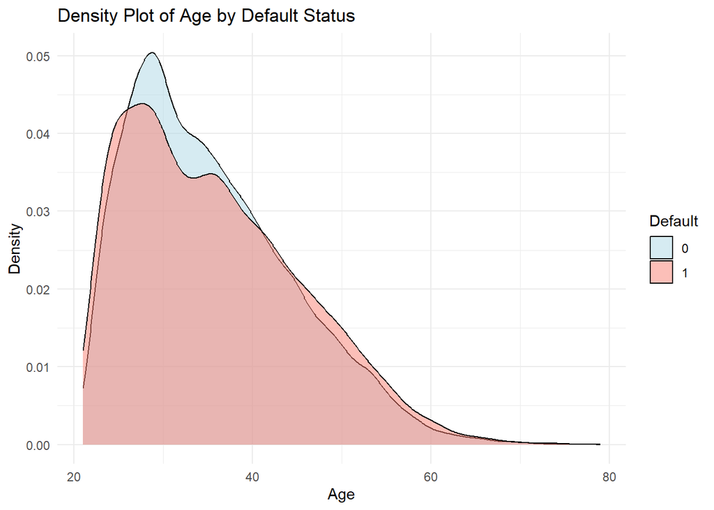

```r
# Density plot of Age by Default Status
ggplot(taiwan_loan, aes(x = Age, fill = Default)) +
  geom_density(alpha = 0.5) +
  labs(title = "Density Plot of Age by Default Status",
       x = "Age",
       y = "Density") +
  scale_fill_manual(values = c("lightblue", "salmon")) +
  theme_minimal()
```

#### Billed to Paid Ratio

```r
# Create Billed_Paid_Ratios
taiwan_loan <- taiwan_loan %>%
  mutate(
    Billed_Paid_Ratio_Sept = ifelse(Pay_Amt_Sept == 0, 0, Bill_Amt_Sept / Pay_Amt_Sept),
    Billed_Paid_Ratio_Aug = ifelse(Pay_Amt_Aug == 0, 0, Bill_Amt_Aug / Pay_Amt_Aug),
    Billed_Paid_Ratio_July = ifelse(Pay_Amt_July == 0, 0, Bill_Amt_July / Pay_Amt_July),
    Billed_Paid_Ratio_June = ifelse(Pay_Amt_June == 0, 0, Bill_Amt_June / Pay_Amt_June),
    Billed_Paid_Ratio_May = ifelse(Pay_Amt_May == 0, 0, Bill_Amt_May / Pay_Amt_May),
    Billed_Paid_Ratio_April = ifelse(Pay_Amt_April == 0, 0, Bill_Amt_April / Pay_Amt_April)
  ) %>%
  mutate(
    Avg_Billed_Paid_Ratio = rowMeans(select(., Billed_Paid_Ratio_Sept, Billed_Paid_Ratio_Aug, Billed_Paid_Ratio_July, Billed_Paid_Ratio_June, Billed_Paid_Ratio_May, Billed_Paid_Ratio_April))
  )
```

#### Repayment Status

The repayment status for past 6 months from April 2005 to September 2005 could add value to our prediction.

```r
table(taiwan_loan$Pay_Status_Sept)
```

```
##
##    -1    -2     0     1     2     3     4     5     6     7     8
##  5686  2759 14737  3688  2667   322    76    26    11     9    19
```

```r
table(taiwan_loan$Pay_Status_Aug)
```

```
##
##    -1    -2     0     1     2     3     4     5     6     7     8
##  6050  3782 15730    28  3927   326    99    25    12    20     1
```

```r
table(taiwan_loan$Pay_Status_July)
```

```
##
##    -1    -2     0     1     2     3     4     5     6     7     8
##  5938  4085 15764     4  3819   240    76    21    23    27     3
```

```r
table(taiwan_loan$Pay_Status_June)
```

```
##
##    -1    -2     0     1     2     3     4     5     6     7     8
##  5687  4348 16455     2  3159   180    69    35     5    58     2
```

```r
table(taiwan_loan$Pay_Status_May)
```

```
##
##    -1    -2     0     2     3     4     5     6     7     8
##  5539  4546 16947  2626   178    84    17     4    58     1
```

```r
table(taiwan_loan$Pay_Status_April)
```

```
##
##    -1    -2     0     2     3     4     5     6     7     8
##  5740  4895 16286  2766   184    49    13    19    46     2
```

From the available information: -1= paid duly, 1= payment one month delay, 2= payment 2 month delay,and so on. But the dataset seems to -2, 0 classes. We can possibly consider 0 and -2 as ‘paid duly’. Based on that seemingly possible assumption, we can modify -2,-1 observations to 0 making our average aggregate computations easier.

```r
# Convert Pay_Status variables to numeric, replacing -1 and -2 with 0
taiwan_loan <- taiwan_loan %>%
  mutate(
    Pay_Status_Sept = as.numeric(replace(as.character(Pay_Status_Sept), Pay_Status_Sept %in% c("-1", "-2"), "0")),
    Pay_Status_Aug = as.numeric(replace(as.character(Pay_Status_Aug), Pay_Status_Aug %in% c("-1", "-2"), "0")),
    Pay_Status_July = as.numeric(replace(as.character(Pay_Status_July), Pay_Status_July %in% c("-1", "-2"), "0")),
    Pay_Status_June = as.numeric(replace(as.character(Pay_Status_June), Pay_Status_June %in% c("-1", "-2"), "0")),
    Pay_Status_May = as.numeric(replace(as.character(Pay_Status_May), Pay_Status_May %in% c("-1", "-2"), "0")),
    Pay_Status_April = as.numeric(replace(as.character(Pay_Status_April), Pay_Status_April %in% c("-1", "-2"), "0"))
  )

# Verify changes
table(taiwan_loan$Pay_Status_Sept)
```

```
##
##     0     1     2     3     4     5     6     7     8
## 23182  3688  2667   322    76    26    11     9    19
```

```r
table(taiwan_loan$Pay_Status_Aug)
```

```
##
##     0     1     2     3     4     5     6     7     8
## 25562    28  3927   326    99    25    12    20     1
```

```r
table(taiwan_loan$Pay_Status_July)
```

```
##
##     0     1     2     3     4     5     6     7     8
## 25787     4  3819   240    76    21    23    27     3
```

```r
table(taiwan_loan$Pay_Status_June)
```

```
##
##     0     1     2     3     4     5     6     7     8
## 26490     2  3159   180    69    35     5    58     2
```

```r
table(taiwan_loan$Pay_Status_May)
```

```
##
##     0     2     3     4     5     6     7     8
## 27032  2626   178    84    17     4    58     1
```

```r
table(taiwan_loan$Pay_Status_April)
```

```
##
##     0     2     3     4     5     6     7     8
## 26921  2766   184    49    13    19    46     2
```

```r
# Aggregate average measure of repayment status across 6 months
taiwan_loan <- taiwan_loan %>%
  mutate(Avg_Pay_Status = rowMeans(select(., Pay_Status_Sept, Pay_Status_Aug, Pay_Status_July, Pay_Status_June, Pay_Status_May, Pay_Status_April)))

# Verify the new aggregated feature
summary(taiwan_loan$Avg_Pay_Status)
```

```
##    Min. 1st Qu.  Median    Mean 3rd Qu.    Max.
##  0.0000  0.0000  0.0000  0.2813  0.3333  6.0000
```

```r
# Convert Pay_Status variables back to factors
taiwan_loan <- taiwan_loan %>%
  mutate(
    Pay_Status_Sept = as.factor(Pay_Status_Sept),
    Pay_Status_Aug = as.factor(Pay_Status_Aug),
    Pay_Status_July = as.factor(Pay_Status_July),
    Pay_Status_June = as.factor(Pay_Status_June),
    Pay_Status_May = as.factor(Pay_Status_May),
    Pay_Status_April = as.factor(Pay_Status_April)
  )
```

### Default

Let’s see how the target variable (*Default*) is distributed with visualizations to get a quick overview.

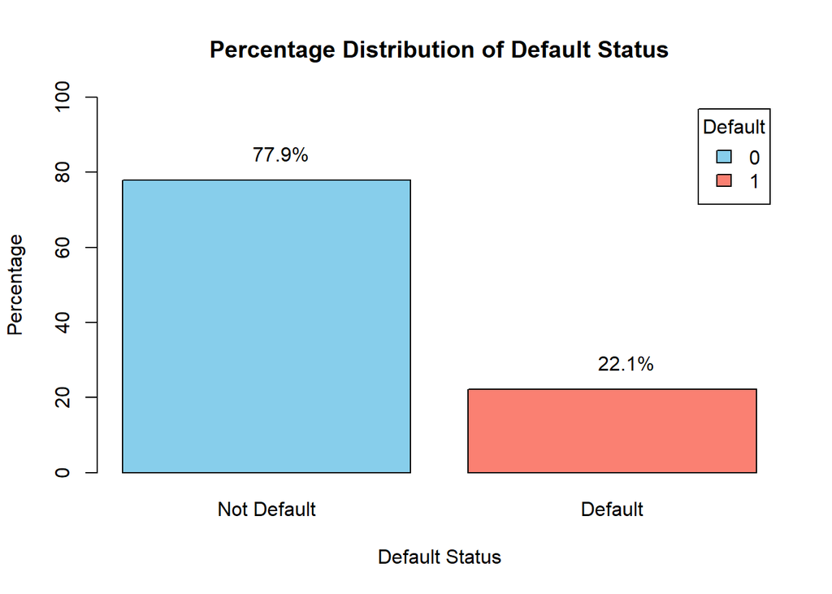

```r
# Calculate percentages of default and non-default
default_counts <- table(taiwan_loan$Default)
default_percentages <- default_counts / sum(default_counts) * 100

# Create a bar plot
barplot(default_percentages,
        main = "Percentage Distribution of Default Status",
        xlab = "Default Status",
        ylab = "Percentage",
        col = c("skyblue", "salmon"),
        names.arg = c("Not Default", "Default"),
        ylim = c(0, 100),
        beside = TRUE,
        legend.text = TRUE,
        args.legend = list(title = "Default")
)

# Add percentage labels on the bars
text(x = barplot(default_percentages, plot = FALSE) + 0.05,
     y = default_percentages + 2,
     labels = paste0(round(default_percentages, 1), "%"),
     col = "black", pos = 3)
```

There are significantly more number of non-defaulters than the defaulters in the dataset.

# Addressing Class Imbalance

Now it is time to address a crucial part of the analysis. There is a significant imbalance between defaulters and non-defaulters in the dataset, with an approximate 20-80 split, respectively. If we build the model with this imbalanced distribution, it will likely be biased towards classifying more non-defaulters and fewer defaulters than actually present *(How Can You Balance Class Imbalance in an ML Model?, 2023)*. Given our main intention to predict potential defaulters, this poses a significant problem.

To mitigate this issue, I will adjust the imbalance from 20-80 to 40-60 split. This distribution will allow the model to learn the underlying patterns of defaulters more effectively while still maintaining the real-world relevance of defaulters always being fewer than non-defaulters. Although a 50-50 split might seem like a good idea, having an equal number of defaulters and non-defaulters is a very rare phenomenon, which does not align with our scenario.

```r
# Set seed for reproducibility
set.seed(84735)

# Calculate the number of samples needed from each class
n_majority <- sum(taiwan_loan$Default == 0)
n_minority <- sum(taiwan_loan$Default == 1)

# Desired balance (e.g., 40% defaults)
desired_minority_proportion <- 0.4

# Calculate the desired number of majority class instances
desired_majority_count <- round(n_minority * (1 - desired_minority_proportion) / desired_minority_proportion)

# Ensure we do not exceed the available majority samples
desired_majority_count <- min(desired_majority_count, n_majority)

# Sample from the majority class
majority_sample <- taiwan_loan %>%
  filter(Default == 0) %>%
  sample_n(size = desired_majority_count, replace = FALSE)

# Combine the majority sample with all minority instances
balanced_dataset <- bind_rows(majority_sample, taiwan_loan %>% filter(Default == 1))

# Check the distribution of 'Default' variable in the balanced dataset
prop.table(table(balanced_dataset$Default))
```

```
##
##   0   1
## 0.6 0.4
```

The balancing of 20-80 split of non-defaulters and defaulters to an extent to 40-60 split is achieved.

# Final Dataset for modelling

We are just a step away from model building. Before that we need to prepare the final dataset required for model building. On a first attempt, I am just going to throw in all the available predictors into the model and so modifying the dataset accordingly and checking for the variable class.

```r
# Final Dataset Preparation
model_data <- balanced_dataset %>%
  select(Credit_Limit, Marital_Status,
         Edu_Level, Gender, Age,
         Avg_Pay_Status, Avg_Billed_Paid_Ratio, Default) %>%
  mutate(Default = factor(ifelse(Default == 0, "No", "Yes")))  # Convert Default to "No" and "Yes"

#structure of dataset
str(model_data)
```

```
## tibble [16,590 × 8] (S3: tbl_df/tbl/data.frame)
##  $ Credit_Limit         : num [1:16590] 20000 30000 400000 110000 270000 310000 250000 50000 360000 50000 ...
##  $ Marital_Status       : Factor w/ 3 levels "1","2","3": 2 1 1 2 2 2 3 1 2 2 ...
##  $ Edu_Level            : Factor w/ 4 levels "1","2","3","4": 2 3 2 2 1 1 3 2 2 1 ...
##  $ Gender               : Factor w/ 2 levels "1","2": 1 2 1 2 2 1 2 1 1 1 ...
##  $ Age                  : num [1:16590] 42 22 30 25 45 32 49 29 29 36 ...
##  $ Avg_Pay_Status       : num [1:16590] 0 0.333 0 0 0 ...
##  $ Avg_Billed_Paid_Ratio: num [1:16590] 18.119 13.962 12.971 0.617 24.515 ...
##  $ Default              : Factor w/ 2 levels "No","Yes": 1 1 1 1 1 1 1 1 1 1 ...
```

```r
# Set seed for reproducibility
set.seed(84735)

# Sample 6,000 rows from the original dataset
loan_sample <- model_data %>% sample_n(4000)
```

We need to check if this sample sufficiently represents the true population (original dataset).

```r
# Compare Default variable distribution
original_default_dist <- prop.table(table(model_data$Default))
sample_default_dist <- prop.table(table(loan_sample$Default))

# Print Default variable distributions
print("Original Default Distribution:")
```

```
## [1] "Original Default Distribution:"
```

```r
print(original_default_dist)
```

```
##
##  No Yes
## 0.6 0.4
```

```r
print("Sampled Default Distribution:")
```

```
## [1] "Sampled Default Distribution:"
```

```r
print(sample_default_dist)
```

```
##
##    No   Yes
## 0.607 0.393
```

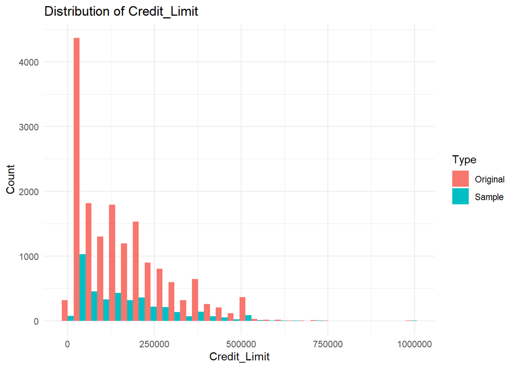

```r
# Compare distributions of other key variables using ggplot2
# Function to plot distributions for comparison
plot_distribution <- function(original, sample, variable) {
  original_df <- data.frame(Value = original, Type = "Original")
  sample_df <- data.frame(Value = sample, Type = "Sample")
  combined_df <- rbind(original_df, sample_df)

  ggplot(combined_df, aes(x = Value, fill = Type)) +
    geom_histogram(position = "dodge", bins = 30) +
    labs(title = paste("Distribution of", variable), x = variable, y = "Count") +
    theme_minimal()
}

# Plot distributions for comparison
plot_distribution(model_data$Credit_Limit, loan_sample$Credit_Limit, "Credit_Limit")
```

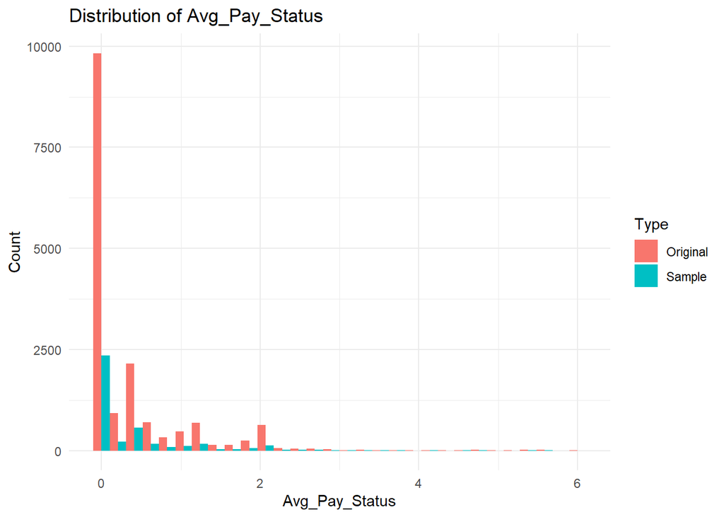

```r
plot_distribution(model_data$Avg_Pay_Status, loan_sample$Avg_Pay_Status, "Avg_Pay_Status")
```

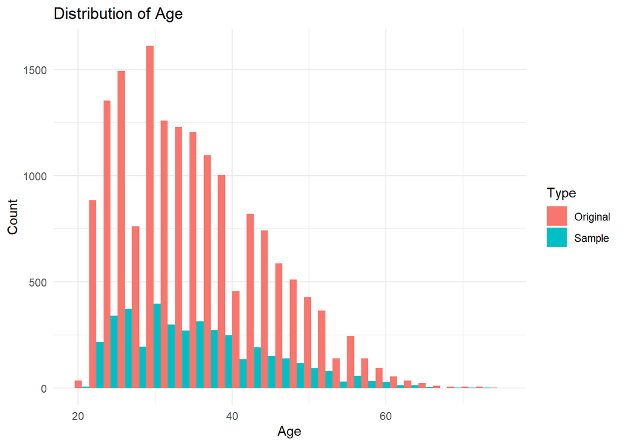

```r
plot_distribution(model_data$Age, loan_sample$Age, "Age")
```

```r
# Compare categorical variables distributions
original_marital_status_dist <- prop.table(table(model_data$Marital_Status))
sample_marital_status_dist <- prop.table(table(loan_sample$Marital_Status))

original_edu_level_dist <- prop.table(table(model_data$Edu_Level))
sample_edu_level_dist <- prop.table(table(loan_sample$Edu_Level))

original_gender_dist <- prop.table(table(model_data$Gender))
sample_gender_dist <- prop.table(table(loan_sample$Gender))

# Print categorical variable distributions
print("Original Marital Status Distribution:")
```

```
## [1] "Original Marital Status Distribution:"
```

```r
print(original_marital_status_dist)
```

```
##
##          1          2          3
## 0.45786618 0.52971670 0.01241712
```

```r
print("Sampled Marital Status Distribution:")
```

```
## [1] "Sampled Marital Status Distribution:"
```

```r
print(sample_marital_status_dist)
```

```
##
##       1       2       3
## 0.45175 0.53750 0.01075
```

```r
print("Original Education Level Distribution:")
```

```
## [1] "Original Education Level Distribution:"
```

```r
print(original_edu_level_dist)
```

```
##
##          1          2          3          4
## 0.34358047 0.47492465 0.16907776 0.01241712
```

```r
print("Sampled Education Level Distribution:")
```

```
## [1] "Sampled Education Level Distribution:"
```

```r
print(sample_edu_level_dist)
```

```
##
##       1       2       3       4
## 0.34675 0.47000 0.17025 0.01300
```

```r
print("Original Gender Distribution:")
```

```
## [1] "Original Gender Distribution:"
```

```r
print(original_gender_dist)
```

```
##
##         1         2
## 0.4086799 0.5913201
```

```r
print("Sampled Gender Distribution:")
```

```
## [1] "Sampled Gender Distribution:"
```

```r
print(sample_gender_dist)
```

```
##
##     1     2
## 0.411 0.589
```

Thanks to the ‘Random Sampling’ technique and the ‘Law of Large Numbers,’ these results indicate that the random sampling process has successfully maintained the original dataset’s distributions and proportions. This is a good indication that our sample is representative of the original dataset, and we can confidently proceed with building our Bayesian logistic regression model to predict credit card defaulters in a hope of possibly saving Taiwan slipping into a recession😆. The whole mission is now on our shoulders!

# Conceptual Model

## CM1: Specifying the Data Model

Our target variable, $Y_i$, is a discrete variable indicating whether or not a person defaults, represented as a binary factor variable (0: No and 1: Yes). Thus, fitting a logistic regression using a Bernoulli probability model is appropriate for our analysis *(Johnson, Ott, & Dogucu, 2021)*. This is represented in the form of a data model as follows:

**Data model**

$$Y_i \mid \beta_0, \beta_1, \ldots, \beta_p \sim \text{Bernoulli}(\pi_i)
\quad \text{with} \quad \log\left(\frac{\pi_i}{1 - \pi_i}\right) =
\beta_0 + \beta_1 X_{i1} + \beta_2 X_{i2} + \ldots + \beta_p X_{ip}$$

**Priors**

$$\beta_0 \sim N(m_0, s_0^2)$$

$$\beta_1 \sim N(m_1, s_1^2)$$

$$\vdots$$

$$\beta_p \sim N(m_p, s_p^2)$$

$$\pi_i = \frac{e^{\beta_0 + \beta_1 X_{i1} + \beta_2 X_{i2} + \ldots +
\beta_p X_{ip}}}{1 + e^{\beta_0 + \beta_1 X_{i1} + \beta_2 X_{i2} +
\ldots + \beta_p X_{ip}}}$$

## CM2: Specification of Priors

Given the absence of specific prior beliefs or background information relevant to Taiwan credit card crisis situation in 2005, I opted for weakly (not very weakly) informative priors. These priors are characterized by a normal distribution with a mean of 0 and a standard deviation of 2.5. This choice reflects a neutral stance, assuming no effect (mean = 0) while allowing for a moderate spread of potential effects (standard deviation = 2.5). The intention behind selecting weakly informative priors, *Stan-Dev (n.d.)*, is to avoid strong assumptions about the data and to let our large amount of data (4K observations) itself strongly influence the model’s outcomes. Additionally, the autoscaling feature adjusts the prior scales based on the dataset’s characteristics, enhancing the model’s adaptability and robustness.

$$\beta_0 \sim \text{Normal}(0, 2.5^2)$$

$$\beta_1 \sim \text{Normal}(0, 2.5^2)$$

$$\beta_2 \sim \text{Normal}(0, 2.5^2)$$

$$\vdots$$

$$\beta_p \sim \text{Normal}(0, 2.5^2)$$

## CM3: Hypothesis Specification

**Credit Limit (**β1)

- **Null Hypothesis (**H0): βi=0
- **Rationale**: The null hypothesis assumes that the credit limit has no effect on the likelihood of defaulting. This is a conservative assumption indicating that without evidence, we assume no impact.

**Average Payment Status (**β2)

- **Null Hypothesis (**H0): βi=0
- **Rationale**: This assumes that the average repayment status does not influence the likelihood of default. This neutral stance reflects the assumption that, in the absence of evidence, payment behavior has no effect on default risk.

**Average Billed-to-Paid Ratio (**β3)

- **Null Hypothesis (**H0): βi=0
- **Rationale**: The null hypothesis posits that the ratio of billed amounts to paid amounts has no effect on default probability. This is a standard approach when no prior research strongly indicates an effect.

**Marital Status (**β4)

- **Null Hypothesis (**H0): βi=0
- **Rationale**: Assumes marital status does not affect the likelihood of defaulting. This neutral assumption is based on the absence of prior evidence suggesting a relationship.

**Education Level (**β5)

- **Null Hypothesis (**H0): βi=0
- **Rationale**: The null hypothesis assumes that education level has no effect on default probability. This conservative stance is taken due to lack of specific prior studies indicating a significant effect.

**Gender (**β6)

- **Null Hypothesis (**H0): βi=0
- **Rationale**: This assumes that gender has no impact on the likelihood of defaulting. This is a neutral assumption reflecting the absence of strong prior evidence which otherwise would lead to gender bias.

**Age (**β7)

- **Null Hypothesis (**H0): βi=0
- **Rationale**: Assumes age does not influence the probability of default. This conservative stance is taken due to lack of specific prior studies indicating a significant effect.

## CM4: Tuning priors

To ensure that these priors are reasonable and to visualize their effects, we run the *stan_glm* with *prior_PD= TRUE*. This will generate samples from the prior predictive distribution, helping us assess if the priors are appropriately specified.

```r
#Loading packages and data

library(bayesrules)
library(rstanarm)
```

```r
library(bayesplot)
library(tidybayes)
library(tidyverse)
library(broom.mixed)
library(tidybayes)
```

```r
# Fit the model with prior predictive checks
credit_model_prior <- stan_glm(
  Default ~ Credit_Limit + Avg_Pay_Status + Avg_Billed_Paid_Ratio + Marital_Status + Edu_Level + Gender + Age,
  data = loan_sample,
  family = binomial,
  prior_intercept = normal(0, 2.5, autoscale = TRUE),
  prior = normal(0, 2.5, autoscale = TRUE),
  chains = 4,
  iter = 5000*2,
  seed = 84735,
  prior_PD = TRUE,  # Prior predictive checks
)
# MCMC diagnostics
      mcmc_trace(credit_model_prior)
```

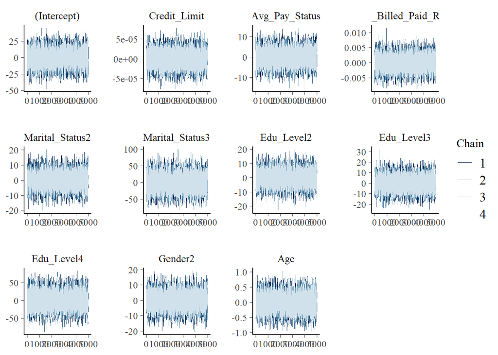

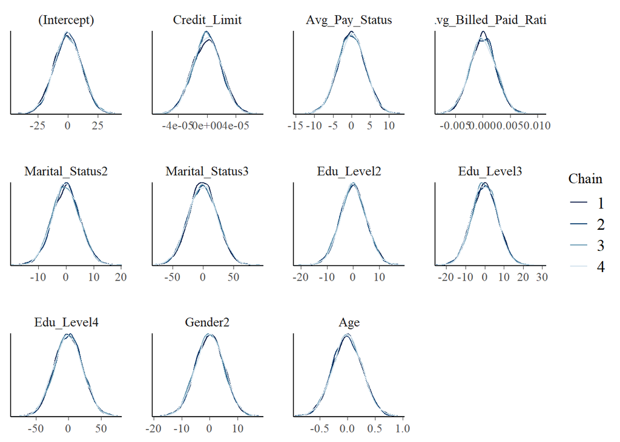

```r
      mcmc_dens_overlay(credit_model_prior)
```

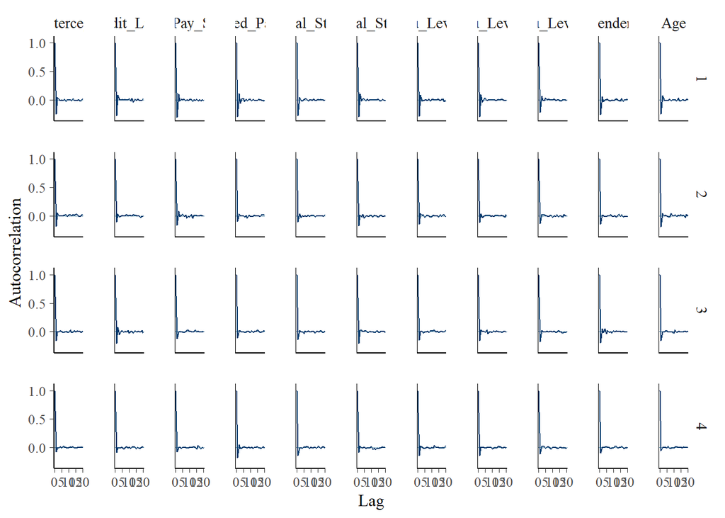

```r
      mcmc_acf(credit_model_prior)
```

```r
prior_summary1 <- prior_summary(credit_model_prior)
prior_summary1
```

```
## Priors for model 'credit_model_prior'
## ------
## Intercept (after predictors centered)
##  ~ normal(location = 0, scale = 2.5)
##
## Coefficients
##   Specified prior:
##     ~ normal(location = [0,0,0,...], scale = [2.5,2.5,2.5,...])
##   Adjusted prior:
##     ~ normal(location = [0,0,0,...], scale = [0.00002,3.68229,0.00240,...])
## ------
## See help('prior_summary.stanreg') for more details
```

```r
prior_summary1$prior$adjusted_scale
```

```
##  [1] 1.967389e-05 3.682294e+00 2.395342e-03 5.013495e+00 2.423977e+01
##  [6] 5.008398e+00 6.650718e+00 2.206762e+01 5.080508e+00 2.716108e-01
```

We observed that while some coefficients aligned closely with the specified priors of Normal(0, 2.5), several coefficients showed significant adjustments beyond this range. Notably, Marital_Status3 and Edu_Level_4 coefficients exhibited standard deviations (20+) far exceeding the initial 2.5 threshold. It is fine as we have set weakly informative priors on the lack of prior knowledge. This adjustment signifies greater uncertainty and potentially larger effects of these predictors on credit default probabilities, accommodating the observed data more flexibly than the originally specified prior.

# Implementing the Model

## IM1: Model 1

Let’s simulate the posterior model for all regression model parameters by doing an *update()* on the *credit_model_prior* simulation in light of this new *loan_sample* data.

```r
# Simulate the model
credit_model_1 <- update(credit_model_prior, prior_PD= FALSE)
```

## IM2: MCMC Evaluation

```r
# MCMC diagnostics
      mcmc_trace(credit_model_1)
```

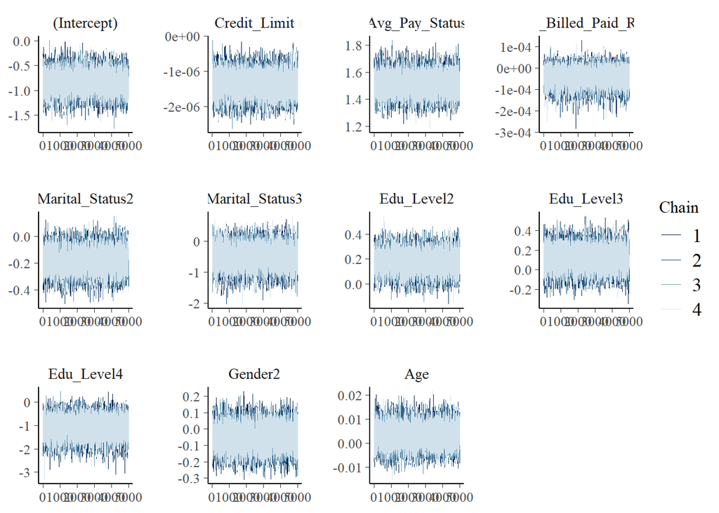

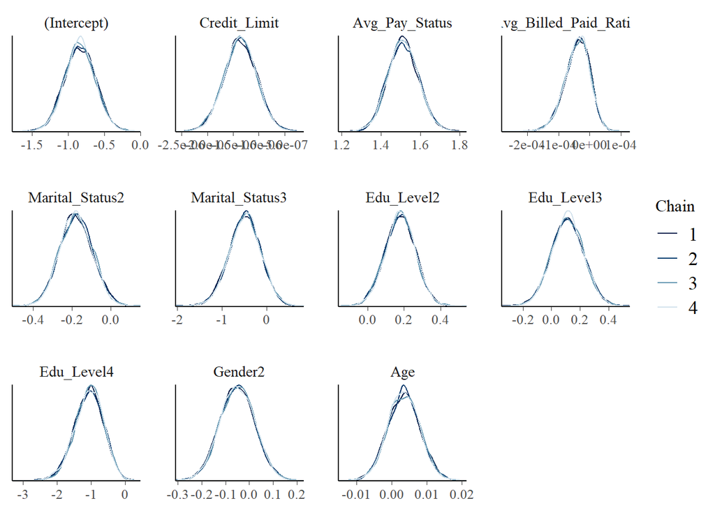

```r
      mcmc_dens_overlay(credit_model_1)
```

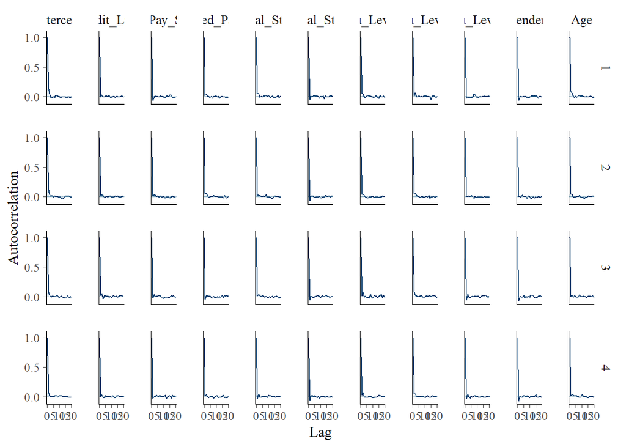

```r
      mcmc_acf(credit_model_1)
```

```r
      neff_ratio(credit_model_1)
```

```
##           (Intercept)          Credit_Limit        Avg_Pay_Status
##               0.77465               0.88915               0.92165
## Avg_Billed_Paid_Ratio       Marital_Status2       Marital_Status3
##               0.88885               0.84765               1.06885
##            Edu_Level2            Edu_Level3            Edu_Level4
##               0.84770               0.79940               1.01455
##               Gender2                   Age
##               1.11790               0.82795
```

```r
      rhat(credit_model_1)
```

```
##           (Intercept)          Credit_Limit        Avg_Pay_Status
##             0.9999951             1.0000202             0.9998546
## Avg_Billed_Paid_Ratio       Marital_Status2       Marital_Status3
##             0.9999206             0.9999306             0.9999486
##            Edu_Level2            Edu_Level3            Edu_Level4
##             1.0001278             1.0001029             1.0000623
##               Gender2                   Age
##             0.9999937             1.0000513
```

```r
      # Summary of the model
      summary(credit_model_1)
```

```
##
## Model Info:
##  function:     stan_glm
##  family:       binomial [logit]
##  formula:      Default ~ Credit_Limit + Avg_Pay_Status + Avg_Billed_Paid_Ratio +
##     Marital_Status + Edu_Level + Gender + Age
##  algorithm:    sampling
##  sample:       20000 (posterior sample size)
##  priors:       see help('prior_summary')
##  observations: 4000
##  predictors:   11
##
## Estimates:
##                         mean   sd   10%   50%   90%
## (Intercept)           -0.8    0.2 -1.1  -0.8  -0.6
## Credit_Limit           0.0    0.0  0.0   0.0   0.0
## Avg_Pay_Status         1.5    0.1  1.4   1.5   1.6
## Avg_Billed_Paid_Ratio  0.0    0.0  0.0   0.0   0.0
## Marital_Status2       -0.2    0.1 -0.3  -0.2  -0.1
## Marital_Status3       -0.5    0.4 -0.9  -0.5   0.0
## Edu_Level2             0.2    0.1  0.1   0.2   0.3
## Edu_Level3             0.1    0.1  0.0   0.1   0.3
## Edu_Level4            -1.1    0.4 -1.6  -1.1  -0.5
## Gender2               -0.1    0.1 -0.1   0.0   0.0
## Age                    0.0    0.0  0.0   0.0   0.0
##
## Fit Diagnostics:
##            mean   sd   10%   50%   90%
## mean_PPD 0.4    0.0  0.4   0.4   0.4
##
## The mean_ppd is the sample average posterior predictive distribution of the outcome variable (for details see help('summary.stanreg')).
##
## MCMC diagnostics
##                       mcse Rhat n_eff
## (Intercept)           0.0  1.0  15493
## Credit_Limit          0.0  1.0  17783
## Avg_Pay_Status        0.0  1.0  18433
## Avg_Billed_Paid_Ratio 0.0  1.0  17777
## Marital_Status2       0.0  1.0  16953
## Marital_Status3       0.0  1.0  21377
## Edu_Level2            0.0  1.0  16954
## Edu_Level3            0.0  1.0  15988
## Edu_Level4            0.0  1.0  20291
## Gender2               0.0  1.0  22358
## Age                   0.0  1.0  16559
## mean_PPD              0.0  1.0  20032
## log-posterior         0.0  1.0   9306
##
## For each parameter, mcse is Monte Carlo standard error, n_eff is a crude measure of effective sample size, and Rhat is the potential scale reduction factor on split chains (at convergence Rhat=1).
```

The graphs indicate a stable MCMC-simulated posterior PDF. The trace plots show the chains intermingle without any systematic patterns, suggesting good mixing. The density plots reveal that the posterior density estimates for each parameter overlap significantly across the chains, indicating consistency according to *Mudigonda (2024)*. The autocorrelation plots demonstrate that the autocorrelation within each chain is close to zero, reflecting efficient sampling. These observations collectively suggest that the posterior PDF estimates are stable. The numerical summaries reinforce this conclusion, with all of the effective sample sizes (*n_eff*) being more than 10,000, and *Rhat* values mostly close to 1.00, indicating sufficient sampling and lack of autocorrelation according to the notes document of Week 4 on Building Simple Normal Regression models (Link: https://canvas.slu.edu/courses/55934/files/4756996?wrap=1).

Let’s see the summaries of these coefficients.

```r
# summary with confidence intervals
tidy(credit_model_1, conf.int = TRUE, conf.level = 0.9999)
```

```
## # A tibble: 11 × 5
##    term                     estimate   std.error    conf.low    conf.high
##    <chr>                       <dbl>       <dbl>       <dbl>        <dbl>
##  1 (Intercept)           -0.834      0.213       -1.74       -0.0218
##  2 Credit_Limit          -0.00000136 0.000000315 -0.00000258 -0.000000174
##  3 Avg_Pay_Status         1.51       0.0782       1.22        1.82
##  4 Avg_Billed_Paid_Ratio -0.0000374  0.0000400   -0.000249    0.000113
##  5 Marital_Status2       -0.180      0.0844      -0.504       0.152
##  6 Marital_Status3       -0.482      0.347       -1.99        0.708
##  7 Edu_Level2             0.180      0.0833      -0.150       0.517
##  8 Edu_Level3             0.112      0.113       -0.324       0.540
##  9 Edu_Level4            -1.05       0.427       -3.09        0.438
## 10 Gender2               -0.0499     0.0735      -0.304       0.212
## 11 Age                    0.00349    0.00460     -0.0129      0.0203
```

## IM3: Hypothesis Checking

Let’s interpret the above posterior model PDF’s and see which of the coefficients are significant using the reference from *Mudigonda (2024)* on Multivariate Normal Models.

**Overview**

#### Correlations- Numerical Features

Having come all the way, we have noticed only two features to be significant among all. The significance of these two variables (*Credit_Limit* and *Avg_Pay_Status*) can also be quickly gleaned from correlations in a different approach. I have created a correlation matrix. It converts relevant columns to numeric, handles the *Default* variable as binary (0 and 1), and computes the correlation matrix using polyserial correlation for the binary target variable.

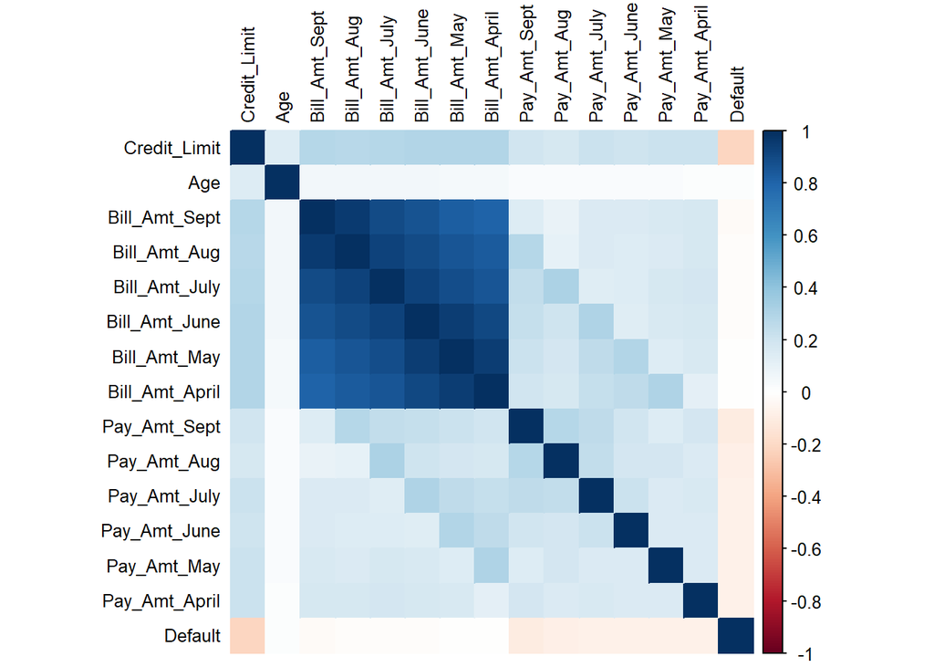

```r
library(ggplot2)
library(reshape2)
library(corrplot)
library(polycor)

# Convert relevant columns to numeric, including Default
taiwan_loan <- taiwan_loan %>%
  mutate(across(c(Credit_Limit, Age, starts_with("Bill_Amt"), starts_with("Pay_Amt")), as.numeric)) %>%
  mutate(Default = as.numeric(as.character(Default)))  # Convert Default from character to numeric

# Select only numeric columns for the correlation matrix
numeric_vars <- taiwan_loan %>%
  select(Credit_Limit, Age, starts_with("Bill_Amt"), starts_with("Pay_Amt"))

# Calculate the correlation matrix for numeric variables
correlation_matrix <- cor(numeric_vars, use = "pairwise.complete.obs")

# Calculate the polyserial correlation for Default with each numeric variable
polyserial_corr <- sapply(numeric_vars, function(x) polyserial(x, taiwan_loan$Default))

# Combine the polyserial correlations with the numeric correlation matrix
correlation_matrix_with_default <- rbind(correlation_matrix, Default = polyserial_corr)
correlation_matrix_with_default <- cbind(correlation_matrix_with_default, Default = c(polyserial_corr, 1))

# Create a heatmap of the correlation matrix including the Default variable
corrplot(correlation_matrix_with_default, method = "color", tl.col = "black", tl.cex = 0.8)
```

```r
# Convert Default back to factor
taiwan_loan <- taiwan_loan %>%
  mutate(Default = as.factor(Default))
```

From the correlation heatmap, it is clear that there are no strong correlations between the *Default* variable and any single numerical variable. This suggests that the likelihood of defaulting among loan holders cannot be solely determined by any single numerical variable alone but might require a combination of variables.

#### Correlations- Factor Features

Let’s see the correlations for categorical variables by performing a Chi-Square test and calculating Cramér’s V with respect to a binary target variable “*Default*”.

```r
# Load necessary libraries
library(vcd)  # For Cramér's V
# Define a function to perform Chi-Square Test and calculate Cramér's V
analyze_categorical_correlation <- function(df, target_var, cat_var) {
  # Create a contingency table
  contingency_table <- table(df[[target_var]], df[[cat_var]])

  # Perform Chi-Square test
  chi_square_test <- chisq.test(contingency_table)

  # Calculate Cramér's V
  cramers_v <- assocstats(contingency_table)$cramer

  return(list(chi_square_test = chi_square_test, cramers_v = cramers_v))
}

# Example with Edu_Level, Marital_Status, and Pay_Status variables
gender_analysis <- analyze_categorical_correlation(taiwan_loan, "Default", "Gender")
edu_level_analysis <- analyze_categorical_correlation(taiwan_loan, "Default", "Edu_Level")
marital_status_analysis <- analyze_categorical_correlation(taiwan_loan, "Default", "Marital_Status")
pay_status_sept_analysis <- analyze_categorical_correlation(taiwan_loan, "Default", "Pay_Status_Sept")
pay_status_aug_analysis <- analyze_categorical_correlation(taiwan_loan, "Default", "Pay_Status_Aug")
pay_status_july_analysis <- analyze_categorical_correlation(taiwan_loan, "Default", "Pay_Status_July")
pay_status_june_analysis <- analyze_categorical_correlation(taiwan_loan, "Default", "Pay_Status_June")
pay_status_may_analysis <- analyze_categorical_correlation(taiwan_loan, "Default", "Pay_Status_May")
pay_status_april_analysis <- analyze_categorical_correlation(taiwan_loan, "Default", "Pay_Status_April")
# Print results

print("Gender Analysis:")
```

```
## [1] "Gender Analysis:"
```

```r
print(gender_analysis)
```

```
## $chi_square_test
##
##  Pearson's Chi-squared test with Yates' continuity correction
##
## data:  contingency_table
## X-squared = 47.709, df = 1, p-value = 4.945e-12
##
##
## $cramers_v
## [1] 0.03996058
```

```r
print("Education Level Analysis:")
```

```
## [1] "Education Level Analysis:"
```

```r
print(edu_level_analysis)
```

```
## $chi_square_test
##
##  Pearson's Chi-squared test
##
## data:  contingency_table
## X-squared = 160.41, df = 3, p-value < 2.2e-16
##
##
## $cramers_v
## [1] 0.07312317
```

```r
print("Marital Status Analysis:")
```

```
## [1] "Marital Status Analysis:"
```

```r
print(marital_status_analysis)
```

```
## $chi_square_test
##
##  Pearson's Chi-squared test
##
## data:  contingency_table
## X-squared = 28.13, df = 2, p-value = 7.791e-07
##
##
## $cramers_v
## [1] 0.03062152
```

```r
print("Pay Status September Analysis:")
```

```
## [1] "Pay Status September Analysis:"
```

```r
print(pay_status_sept_analysis)
```

```
## $chi_square_test
##
##  Pearson's Chi-squared test
##
## data:  contingency_table
## X-squared = 5327.8, df = 8, p-value < 2.2e-16
##
##
## $cramers_v
## [1] 0.4214192
```

```r
print("Pay Status August Analysis:")
```

```
## [1] "Pay Status August Analysis:"
```

```r
print(pay_status_aug_analysis)
```

```
## $chi_square_test
##
##  Pearson's Chi-squared test
##
## data:  contingency_table
## X-squared = 3464.2, df = 8, p-value < 2.2e-16
##
##
## $cramers_v
## [1] 0.3398131
```

```r
print("Pay Status July Analysis:")
```

```
## [1] "Pay Status July Analysis:"
```

```r
print(pay_status_july_analysis)
```

```
## $chi_square_test
##
##  Pearson's Chi-squared test
##
## data:  contingency_table
## X-squared = 2608.8, df = 8, p-value < 2.2e-16
##
##
## $cramers_v
## [1] 0.2948897
```

```r
print("Pay Status June Analysis:")
```

```
## [1] "Pay Status June Analysis:"
```

```r
print(pay_status_june_analysis)
```

```
## $chi_square_test
##
##  Pearson's Chi-squared test
##
## data:  contingency_table
## X-squared = 2321.9, df = 8, p-value < 2.2e-16
##
##
## $cramers_v
## [1] 0.2782028
```

```r
print("Pay Status May Analysis:")
```

```
## [1] "Pay Status May Analysis:"
```

```r
print(pay_status_may_analysis)
```

```
## $chi_square_test
##
##  Pearson's Chi-squared test
##
## data:  contingency_table
## X-squared = 2175.7, df = 7, p-value < 2.2e-16
##
##
## $cramers_v
## [1] 0.2693013
```

```r
print("Pay Status April Analysis:")
```

```
## [1] "Pay Status April Analysis:"
```

```r
print(pay_status_april_analysis)
```

```
## $chi_square_test
##
##  Pearson's Chi-squared test
##
## data:  contingency_table
## X-squared = 1871.8, df = 7, p-value < 2.2e-16
##
##
## $cramers_v
## [1] 0.2497839
```

It is clear that no other factor variable has good enough correlations with *Default* except the variables indicating repayment status with a moderate strength across all months.

## IM4: Model 2

Let’s fit a new model just with the newly identified significant features *Credit_Limit* and *Avg_Repay_Status* to see how well model performs using only these two predictors.

```r
# Fit the Bayesian logistic regression model
credit_model_2 <- stan_glm(
  Default ~ Credit_Limit + Avg_Pay_Status ,
  data = loan_sample,
  family = binomial,
  prior_intercept = normal(0, 2.5, autoscale = TRUE),
  prior = normal(0, 2.5, autoscale = TRUE),
  chains = 4,
  iter = 5000 * 2,
  seed = 84735
)
# MCMC diagnostics
      mcmc_trace(credit_model_1)
```

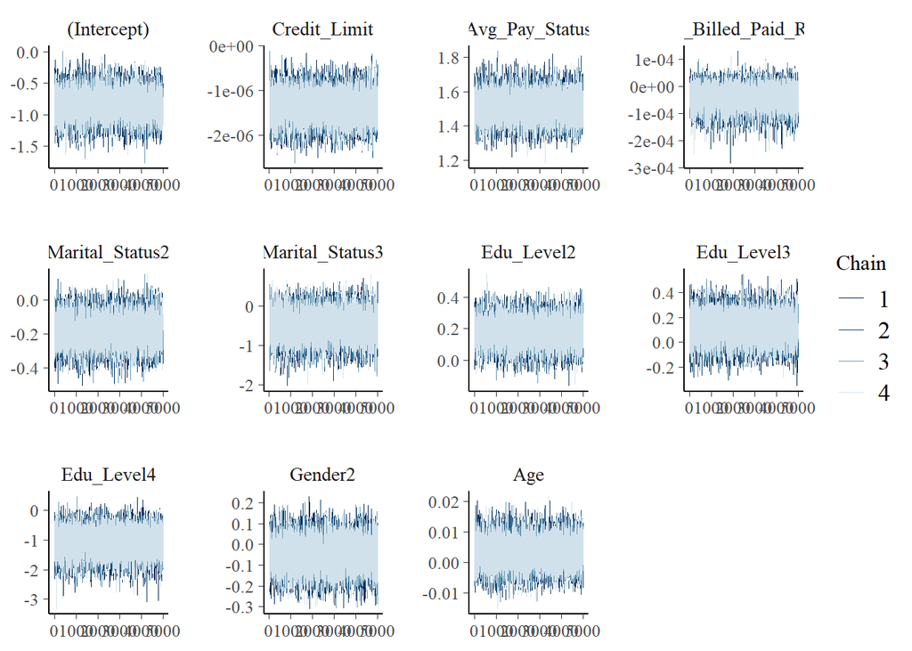

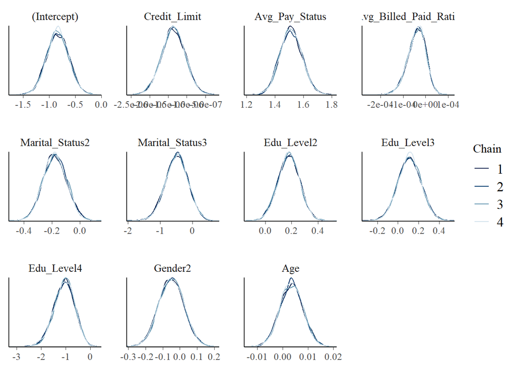

```r
      mcmc_dens_overlay(credit_model_1)
```

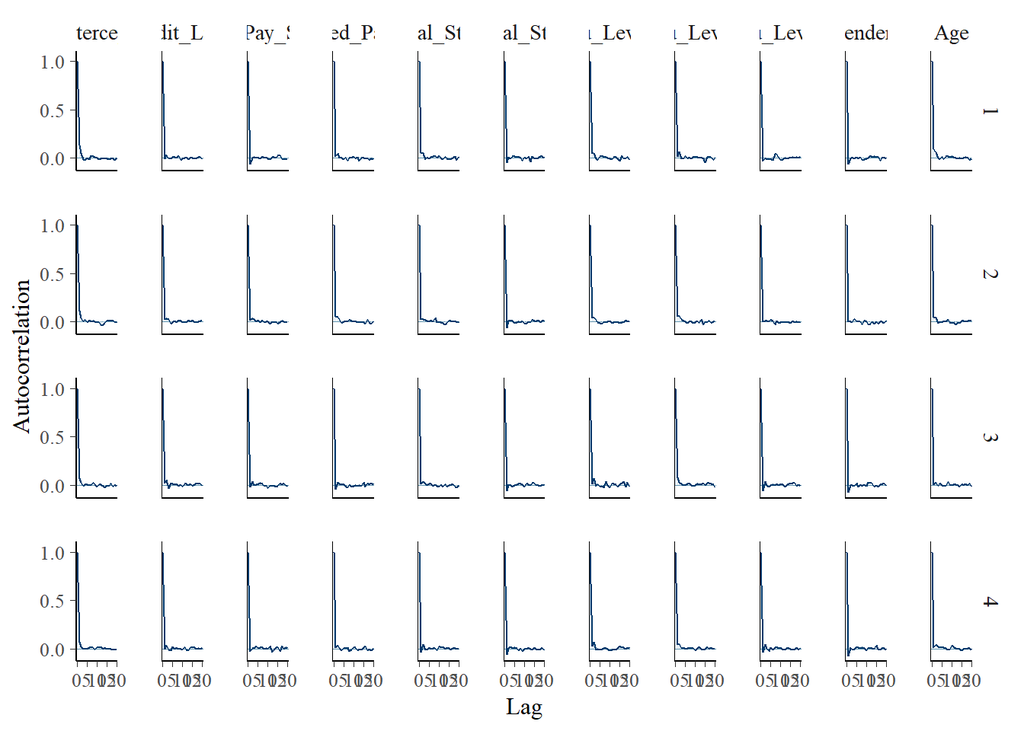

```r
      mcmc_acf(credit_model_1)
```

```r
      neff_ratio(credit_model_1)
```

```
##           (Intercept)          Credit_Limit        Avg_Pay_Status
##               0.77465               0.88915               0.92165
## Avg_Billed_Paid_Ratio       Marital_Status2       Marital_Status3
##               0.88885               0.84765               1.06885
##            Edu_Level2            Edu_Level3            Edu_Level4
##               0.84770               0.79940               1.01455
##               Gender2                   Age
##               1.11790               0.82795
```

```r
      rhat(credit_model_1)
```

```
##           (Intercept)          Credit_Limit        Avg_Pay_Status
##             0.9999951             1.0000202             0.9998546
## Avg_Billed_Paid_Ratio       Marital_Status2       Marital_Status3
##             0.9999206             0.9999306             0.9999486
##            Edu_Level2            Edu_Level3            Edu_Level4
##             1.0001278             1.0001029             1.0000623
##               Gender2                   Age
##             0.9999937             1.0000513
```

```r
      # Summary of the model
      summary(credit_model_1)
```

```
##
## Model Info:
##  function:     stan_glm
##  family:       binomial [logit]
##  formula:      Default ~ Credit_Limit + Avg_Pay_Status + Avg_Billed_Paid_Ratio +
##     Marital_Status + Edu_Level + Gender + Age
##  algorithm:    sampling
##  sample:       20000 (posterior sample size)
##  priors:       see help('prior_summary')
##  observations: 4000
##  predictors:   11
##
## Estimates:
##                         mean   sd   10%   50%   90%
## (Intercept)           -0.8    0.2 -1.1  -0.8  -0.6
## Credit_Limit           0.0    0.0  0.0   0.0   0.0
## Avg_Pay_Status         1.5    0.1  1.4   1.5   1.6
## Avg_Billed_Paid_Ratio  0.0    0.0  0.0   0.0   0.0
## Marital_Status2       -0.2    0.1 -0.3  -0.2  -0.1
## Marital_Status3       -0.5    0.4 -0.9  -0.5   0.0
## Edu_Level2             0.2    0.1  0.1   0.2   0.3
## Edu_Level3             0.1    0.1  0.0   0.1   0.3
## Edu_Level4            -1.1    0.4 -1.6  -1.1  -0.5
## Gender2               -0.1    0.1 -0.1   0.0   0.0
## Age                    0.0    0.0  0.0   0.0   0.0
##
## Fit Diagnostics:
##            mean   sd   10%   50%   90%
## mean_PPD 0.4    0.0  0.4   0.4   0.4
##
## The mean_ppd is the sample average posterior predictive distribution of the outcome variable (for details see help('summary.stanreg')).
##
## MCMC diagnostics
##                       mcse Rhat n_eff
## (Intercept)           0.0  1.0  15493
## Credit_Limit          0.0  1.0  17783
## Avg_Pay_Status        0.0  1.0  18433
## Avg_Billed_Paid_Ratio 0.0  1.0  17777
## Marital_Status2       0.0  1.0  16953
## Marital_Status3       0.0  1.0  21377
## Edu_Level2            0.0  1.0  16954
## Edu_Level3            0.0  1.0  15988
## Edu_Level4            0.0  1.0  20291
## Gender2               0.0  1.0  22358
## Age                   0.0  1.0  16559
## mean_PPD              0.0  1.0  20032
## log-posterior         0.0  1.0   9306
##
## For each parameter, mcse is Monte Carlo standard error, n_eff is a crude measure of effective sample size, and Rhat is the potential scale reduction factor on split chains (at convergence Rhat=1).
```

```r
# summary with confidence intervals
 tidy(credit_model_2, conf.int = TRUE, conf.level = 0.9999)
```

```
## # A tibble: 3 × 5
##   term              estimate   std.error    conf.low    conf.high
##   <chr>                <dbl>       <dbl>       <dbl>        <dbl>
## 1 (Intercept)    -0.756      0.0642      -1.00       -0.508
## 2 Credit_Limit   -0.00000134 0.000000291 -0.00000250 -0.000000244
## 3 Avg_Pay_Status  1.52       0.0769       1.25        1.80
```

Based on the confidence intervals observed, we reject the null hypothesis ($H_0$) for *Credit_Limit* and *Avg_Pay_Status* coefficients due to their confidence intervals not including zero as suggested by *Mudigonda (2024)*, indicating these variables have a statistically significant impact on the log(odds of default).

## IM5: Model comparison

### Simple Classification

We shall compare how well these two models classify predicted outcome of default into a binary yes-or-no classification of Y (Default) with a cut-off of 50% as suggested by *(Johnson, Ott, & Dogucu, 2021)*. This cutoff represents the probability threshold above which an individual is classified as likely to default on their credit card payments.

```r
# Generate classification summary for model 1
set.seed(84735)
classification_summary(model = credit_model_1, data = loan_sample, cutoff = 0.5)
```

```
## $confusion_matrix
##    y    0   1
##   No 2223 205
##  Yes  931 641
##
## $accuracy_rates
##
## sensitivity      0.4077608
## specificity      0.9155684
## overall_accuracy 0.7160000
```

```r
# Generate classification summary for model 2
set.seed(84735)
classification_summary(model = credit_model_2, data = loan_sample, cutoff = 0.5)
```

```
## $confusion_matrix
##    y    0   1
##   No 2227 201
##  Yes  935 637
##
## $accuracy_rates
##
## sensitivity      0.4052163
## specificity      0.9172158
## overall_accuracy 0.7160000
```

Both the models produce very similar results on all 3 metrics. Overall they correctly classified 71.6% of total test cases indicated by the metric- *overall_accuracy*. Although this is close to good enough, a closer look at the results show that our model has performed very good at predicting who will not default the loan than who will default. Among the 2428 customers who did not default, we correctly classified 2227 or around 91.5% indicated by the metric- *specificity* or *true negative rate*. In contrast, we did a not so good job in predicting who will actually default as the model has classified only 637 out of 1572 or around 40.5% indicated by the metric- *sensitivity* or *true positive rate*.

### Cross-validation Method

That’s okay! We shall modify the classification cut-off by bringing it down from 0.5 to 0.3 to suit our main goal of predicting more defaulters rather than solely focusing on overall accuracy rates. By this 0.3 cut-off, we will classify a test case as default if there is even a 30% chance of default. In order to avoid any possible bias in training and testing *credit_model_1* using the same data, we also need to apply the method of 10-fold cross-validation using *classification_summary_CV* as suggested by *(Johnson, Ott, & Dogucu, 2021).*

```r
set.seed(84735)

# Model 1 cross-validation
cv_accuracy_1 <- classification_summary_cv(
  model = credit_model_1,
  data = loan_sample,
  cutoff = 0.3,
  k = 10  # Specify the number of folds for cross-validation
)
cv_accuracy_1$cv
```

```
##   sensitivity specificity overall_accuracy
## 1   0.7558798   0.5594461           0.6365
```

```r
set.seed(84735)

# Model 2 cross-validation
cv_accuracy_2 <- classification_summary_cv(
  model = credit_model_2,
  data = loan_sample,
  cutoff = 0.3,
  k = 10  # Specify the number of folds for cross-validation
)
cv_accuracy_2$cv
```

```
##   sensitivity specificity overall_accuracy
## 1   0.7429464   0.5986054          0.65475
```

By making it easier to classify default, the sensitivity made a leap from 40% to 75.5% in model 1 and 74.3% in model 2. But this was achieved at the cost of making it more difficult to predict who will not default. As we can see in the results, the specificity dropped from 91% to 56% in model 1 and 60% in model 2, and so the model is more prone to classify someone as defaulter more often than usual.

### Expected Log-Predictive Density (ELPD)

We shall also measure the overall compatibility of new data points with their posterior predictive models with ELPD method as suggested by *(Johnson, Ott, & Dogucu, 2021)*.

```r
#Calculate ELPD for the models
loo_1 <- loo(credit_model_1)
loo_2 <- loo(credit_model_2)

#Compare the ELPD for the 2 models
loo_compare(loo_1, loo_2)
```

```
##                elpd_diff se_diff
## credit_model_1  0.0       0.0
## credit_model_2 -5.1       5.2
```

# Conclusions

## C1: Addressing Initial Research Questions

1. What are the key features that significantly predict whether a client will default on their credit card payments?

   Recalling from the section of Hypothesis Checking (IM3), repayment status (*Avg_Repay_Status*) and *Credit_Limit* are the two features that stood out as significant and were used to build Model 2 in predicting the loan defaulters.
2. In predicting credit card default rates, which category—demographic factors or past payment behaviors—provides more significant insights or predictive power?

   Regarding the prediction of credit card default rates, the tidy summaries from Model 2 (IM4) illustrate that both Credit_Limit and Avg_Pay_Status are significant predictors. Notably, Avg_Pay_Status exhibits a larger coefficient (1.52), suggesting it holds greater predictive power compared to Credit_Limit, which has a much smaller coefficient (-1.344e-06). This was also proved by the calculating the odds of these coefficients in that section impying that average repayment status being more useful than credit limit in predicting defaults.

## C2: Limitations

Few key limitations are,

- Bayesian methods shine when prior beliefs or knowledge can be effectively integrated, enhancing model robustness and interpretation. With a large dataset (4k rows) and weakly informative priors, the posterior tends to be driven more by the data itself rather than the priors, potentially reducing the distinct advantages of Bayesian inference compared to less computationally intensive frequentist approaches. Therefore, although I am not sure, for my analysis, the computational resources required for Bayesian analysis might not yield substantial additional insights compared to more straightforward methods.
- The documentation of this dataset is not sufficient enough in understanding some of the classes of variables along with unspecified encoding. This created ambiguity on few of the classes of variables. So, I had to make quite a number of assumptions on those ambiguous classes of variables. Therefore, the data quality, completeness, and accuracy may affect the robustness of conclusion drawn.
- Possible multicollinearity between features was overlooked.
- The findings and models developed may be specific to the dataset and conditions of the study (e.g., Taiwanese credit card defaults in 2005). Generalizing to other demographics or time periods requires careful validation and possibly adaptation of models.

## C3: Additional Research Questions

1. **Research Question 1:** How do economic factors, such as GDP growth rates or unemployment levels, interact with demographic and repayment behavior variables to influence credit card default rates?

   **Approach for Data Collection:** Economic data can be collected periodically from government reports, central banks, and economic research institutions.
2. **Research Question 2:** How does salary, behavioral factors, such as spending habits, savings rates, or financial literacy, contribute to predicting credit card default rates when combined with demographic and repayment variables?

   **Approach for Data Collection:** By conducting surveys or utilize transactional data (with appropriate consent and privacy measures) to gather behavioral insights from credit card users.

## C4: Potential Implications

- The conversion of unknown classes (e.g., converting -2 and 0 to 0) holding a good number of variables in it into already known categories was performed extensively. This preprocessing step, while necessary for analysis, potentially introduced biases or inaccuracies in the model predictions.
- With the prime goal of predicting more potential defaulters, prioritizing sensitivity over specificity in the model design might lead to identifying more true positives (default cases), but, on the other hand, it could inadvertently reject genuine loan applicants who do not fit typical risk profiles.
- The significant class imbalances present in the dataset may introduce bias towards the majority class, potentially leading to skewed predictions and decision-making processes that favor certain groups over others like gender bias.

# Reflections

## R1& R2: Addressing my Challenges

Selecting the right dataset presented an initial challenge due to the vast array of options available. I found myself caught in an exhaustive search for the ‘perfect’ dataset that aligns with my interests. However, I’ve come to realize that during the learning phase, it’s not just about finding the best possible dataset initially, but it’s more about making optimal choices within a given timeframe and continuously experimenting and learning from multiple datasets to improve my skills.

Defining research questions became clearer once I selected the dataset for classifying loan defaulters. However, conducting extensive Exploratory Data Analysis (EDA) for the first time was challenging. I went through multiple Kaggle notebooks on this dataset to understand the EDA process. Additionally, selecting and engineering features, particularly aggregating past payment behaviors across multiple months, posed significant challenges. As there is no definitive line to mark a dataset as ‘fit’ for model building, the decision of making features ready while maintaining simplicity and relevancy is quite a challenge, which I am learning through experience. Documentation also takes a whole lot time everytime which always wonders me how it just happens unknowingly.  
Two psychological behaviors I am more concerned to work upon: Aiming for Perfection everytime, and obsession of making first step itself right/correct without realizing that it is not possible in the law of the nature.

# References

Graff, V. (2023, April 20). Dimension Reduction: Facing the Curse of Dimensionality. Medium. https://towardsdatascience.com/dimension-reduction-facing-the-curse-of-dimensionality-63a743e4b199

How can you balance class imbalance in an ML model? (2023, September 12). https://www.linkedin.com/advice/1/how-can-you-balance-class-imbalance-ml-model

Johnson, A. A., Ott, M. Q., & Dogucu, M. (2021). *Bayes Rules! An Introduction to Applied Bayesian Modeling.* https://www.bayesrulesbook.com/

Mudigonda, S. (2024). *Video lecture on Multivariate Normal Models.* Saint Louis University.  
https://canvas.slu.edu/courses/55934/pages/6-dot-3-%7C-learning-materials?module_item_id=1667250

Notes document of Week 4 on Building Simple Normal Regression models: https://canvas.slu.edu/courses/55934/files/4756996?wrap=1

Stan-Dev. (n.d.). *Prior Choice Recommendations*. GitHub. https://github.com/stan-dev/stan/wiki/Prior-Choice-Recommendations

*The Taiwan Credit Card Crisis - Financial Ethics*. (2011, October 5). Seven Pillars Institute. https://sevenpillarsinstitute.org/case-studies/taiwans-credit-card-crisis/

*UCI Machine Learning Repository*. (n.d.). https://archive.ics.uci.edu/dataset/350/default+of+credit+card+clients